# Raminski_UCB_R_Class_Asgt_6

Michael Raminski

## Diary

For this assignment I used a database featuring the 2016 fantasy football statistics of the top 50 offensive players at each position.

Data Source: https://fantasydata.com/nfl-stats/nfl-fantasy-football-stats.aspx

For some reason when I used “sapply” with both the quantile and the fivenum functions, the results were splightly different. The differences were very small, but I had thought that these functions should be doing the same thing.

Setting “options(digits=3)” didn’t seem to take effect on my numbers, they were still resulting in more than three decimals.

## Summary of Results

Task 2 The box plots provided valuable insights into the data: QB- quarterbacks have the largest disparity between the Q1 and Q3 values, that means that it is very important to own a top tier quarterback. RB- Running backs have the biggest disparity between the top scorer and the median scorer of any position. That means there is value in getting an elite running back versus just an average back. TE- Tight Ends are the lowest scoring position. The distribution of points scored per game between tight ends in almost symmetrical, so it may resemble a normal distribtuion WR- Wide receivers are the only poistion with outliers (at the top). This suggests that there are stand out wide receivers, however, the difference between the top scorers and the median is not as pronounced as quarterbacks and running backs. Additionally, wide receivers have by far the smallest spread of values between Q1 and Q3, meaning there is a large middle tier of wide recievers who are almost interchangable. The violin plots also reinforced this as the showed a very peaked distribution around the median.

Task 3 The scatterplots were not very revealing, it seems that the only strong linear relationship was for between points per game and touches per game among running backs.

I ran the correlations among all variables for each position using each of the pearson, spearman and kendall methods. However, I will focus on the pearson results. The correlation results were interesting, but they were much more compelling looking at the corrgrams. I used various style approaches to the corrgrams, but havent yet found a preference among the options for the lower diagonal. The correlation results were telling, but running the partial correlations was even more interesting because it isolated the variables. I saw some interesting results when running the pcor() function, although I wasn’t exactly sure if I should be controlling for all other variables, or controlling only for the variables that I suspected may be related.

## Assignment

### Task 1

#### Load packages and set the number of digits used to 3

#### Import data

```r
fantasy <- read.csv("fantasy_stats_3.csv")
fantasy <- tbl_df(fantasy)
fantasy
```

```
## # A tibble: 200 × 37
##    Position_Rank           Player Position   Team Games_Played Completions
##            <int>           <fctr>   <fctr> <fctr>        <int>       <int>
## 1              1    Aaron Rodgers       QB     GB           16         401
## 2              2        Matt Ryan       QB    ATL           16         373
## 3              3       Drew Brees       QB     NO           16         471
## 4              4      Andrew Luck       QB    IND           15         346
## 5              5     Kirk Cousins       QB    WAS           16         406
## 6              6     Dak Prescott       QB    DAL           16         311
## 7              7 Matthew Stafford       QB    DET           16         388
## 8              8     Tyrod Taylor       QB    BUF           15         270
## 9              9    Blake Bortles       QB    JAX           16         368
## 10            10       Derek Carr       QB    OAK           15         356
## # ... with 190 more rows, and 31 more variables: Pass_Attempts <int>,
## #   Pass_Yards <int>, Pass_TD <int>, Interceptions <int>, QB_Rating <int>,
## #   Rush_Attempts <int>, Rush_Yards <int>, Rush_TD <int>, Targets <int>,
## #   Receptions <int>, Longest_Reception <int>, Receiving_TD <int>,
## #   Receiving_Yards <int>, Fumbles <int>, Fumbles_Lost <int>,
## #   Total_Fantasy_Points <dbl>, Pass_Attempts_Per_Game <dbl>,
## #   Pass_Yards_Per_Game <dbl>, Pass_TD_Per_Game <dbl>,
## #   Pass_TD_Int_Ratio <dbl>, Rush_Yards_Per_Game <dbl>,
## #   Rush_Attempts_Per_Game <dbl>, Rush_Yards_Per_Attempt <dbl>,
## #   Rush_TD_Per_Game <dbl>, Touches_Per_Game <dbl>,
## #   Targets_Per_Game <dbl>, Reception_Percent <dbl>,
## #   Reception_TD_Per_Game <dbl>, Yards_Per_Target <dbl>,
## #   Yards_Per_Reception <dbl>, Fantasy_PPG <dbl>
```

#### Split the data into 4 data frames by position, eliminate the players toward the bottom of points scored (as this may lead to skew), and select only the most relevant stats for each position

#### Describe the data

##### “summary” function

```r
summary(qb[,-1])
```

[output not shown]

```r
summary(rb[,-1])
```

```
##  Rush_Yards_Per_Game Rush_Attempts_Per_Game Rush_Yards_Per_Attempt
##  Min.   : 10.4       Min.   : 2.44          Min.   :3.18
##  1st Qu.: 37.7       1st Qu.: 8.89          1st Qu.:3.90
##  Median : 55.6       Median :13.37          Median :4.26
##  Mean   : 54.9       Mean   :12.73          Mean   :4.37
##  3rd Qu.: 73.4       3rd Qu.:16.71          3rd Qu.:4.87
##  Max.   :105.7       Max.   :21.75          Max.   :5.94
##  Rush_TD_Per_Game Touches_Per_Game Targets_Per_Game Reception_Percent
##  Min.   :0.000    Min.   : 6.19    Min.   :0.50     Min.   :0.381
##  1st Qu.:0.245    1st Qu.:11.31    1st Qu.:2.36     1st Qu.:0.739
##  Median :0.375    Median :15.94    Median :3.07     Median :0.786
##  Mean   :0.448    Mean   :15.22    Mean   :3.27     Mean   :0.768
##  3rd Qu.:0.604    3rd Qu.:18.86    3rd Qu.:3.92     3rd Qu.:0.813
##  Max.   :1.125    Max.   :28.00    Max.   :7.83     Max.   :0.929
##   Fantasy_PPG
##  Min.   : 5.70
##  1st Qu.: 7.49
##  Median :10.50
##  Mean   :10.75
##  3rd Qu.:12.56
##  Max.   :20.49
```

```r
summary(wr[,-1])
```

```
##  Targets_Per_Game Reception_Percent Reception_TD_Per_Game Yards_Per_Target
##  Min.   : 5.06    Min.   :0.483     Min.   :0.188         Min.   : 5.85
##  1st Qu.: 6.92    1st Qu.:0.579     1st Qu.:0.301         1st Qu.: 7.61
##  Median : 7.69    Median :0.620     Median :0.375         Median : 8.42
##  Mean   : 7.98    Mean   :0.630     Mean   :0.419         Mean   : 8.35
##  3rd Qu.: 9.25    3rd Qu.:0.689     3rd Qu.:0.500         3rd Qu.: 9.02
##  Max.   :10.81    Max.   :0.765     Max.   :0.875         Max.   :10.92
##  Yards_Per_Reception  Fantasy_PPG
##  Min.   : 9.56       Min.   : 7.12
##  1st Qu.:12.07       1st Qu.: 7.95
##  Median :13.13       Median : 8.54
##  Mean   :13.38       Mean   : 9.27
##  3rd Qu.:14.64       3rd Qu.:10.13
##  Max.   :17.95       Max.   :13.42
```

```r
summary(te[,-1])
```

```
##  Targets_Per_Game Reception_Percent Reception_TD_Per_Game Yards_Per_Target
##  Min.   :3.53     Min.   :0.533     Min.   :0.077         Min.   : 5.89
##  1st Qu.:4.75     1st Qu.:0.629     1st Qu.:0.188         1st Qu.: 7.56
##  Median :5.93     Median :0.679     Median :0.364         Median : 7.81
##  Mean   :5.87     Mean   :0.677     Mean   :0.335         Mean   : 8.15
##  3rd Qu.:6.80     3rd Qu.:0.726     3rd Qu.:0.438         3rd Qu.: 8.69
##  Max.   :8.25     Max.   :0.787     Max.   :0.625         Max.   :14.21
##  Yards_Per_Reception  Fantasy_PPG
##  Min.   : 8.48       Min.   :4.39
##  1st Qu.:10.34       1st Qu.:5.40
##  Median :11.60       Median :6.77
##  Mean   :12.09       Mean   :6.71
##  3rd Qu.:13.25       3rd Qu.:7.88
##  Max.   :21.60       Max.   :9.00
```

##### “sapply” function

```r
sapply(qb[,-1],quantile, na.rm=TRUE)
```

```
##      Pass_Attempts_Per_Game Pass_Yards_Per_Game Pass_TD_Per_Game
## 0%                     20.8                 140             1.00
## 25%                    34.0                 236             1.25
## 50%                    36.1                 263             1.56
## 75%                    37.9                 277             2.06
## 100%                   42.1                 326             2.50
##      Pass_TD_Int_Ratio Rush_Yards_Per_Game Rush_Attempts_Per_Game
## 0%                1.14              -0.562                  0.875
## 25%               1.62               3.625                  1.438
## 50%               2.25               9.375                  2.875
## 75%               4.00              22.438                  4.000
## 100%             14.00              38.667                  6.333
##      Fantasy_PPG
## 0%          12.5
## 25%         16.0
## 50%         17.0
## 75%         18.1
## 100%        23.8
```

```r
sapply(rb[,-1],quantile, na.rm=TRUE)
```

```
##      Rush_Yards_Per_Game Rush_Attempts_Per_Game Rush_Yards_Per_Attempt
## 0%                  10.4                   2.44                   3.18
## 25%                 37.7                   8.89                   3.90
## 50%                 55.6                  13.37                   4.26
## 75%                 73.4                  16.71                   4.87
## 100%               105.7                  21.75                   5.94
##      Rush_TD_Per_Game Touches_Per_Game Targets_Per_Game Reception_Percent
## 0%              0.000             6.19             0.50             0.381
## 25%             0.245            11.31             2.36             0.739
## 50%             0.375            15.94             3.07             0.786
## 75%             0.604            18.86             3.92             0.813
## 100%            1.125            28.00             7.83             0.929
##      Fantasy_PPG
## 0%          5.70
## 25%         7.49
## 50%        10.50
## 75%        12.56
## 100%       20.49
```

```r
sapply(wr[,-1],quantile, na.rm=TRUE)
```

```
##      Targets_Per_Game Reception_Percent Reception_TD_Per_Game
## 0%               5.06             0.483                 0.188
## 25%              6.92             0.579                 0.301
## 50%              7.69             0.620                 0.375
## 75%              9.25             0.689                 0.500
## 100%            10.81             0.765                 0.875
##      Yards_Per_Target Yards_Per_Reception Fantasy_PPG
## 0%               5.85                9.56        7.12
## 25%              7.61               12.07        7.95
## 50%              8.42               13.13        8.54
## 75%              9.02               14.64       10.13
## 100%            10.92               17.95       13.42
```

```r
sapply(te[,-1],quantile, na.rm=TRUE)
```

```
##      Targets_Per_Game Reception_Percent Reception_TD_Per_Game
## 0%               3.53             0.533                0.0769
## 25%              4.75             0.629                0.1875
## 50%              5.93             0.679                0.3636
## 75%              6.80             0.726                0.4375
## 100%             8.25             0.787                0.6250
##      Yards_Per_Target Yards_Per_Reception Fantasy_PPG
## 0%               5.89                8.48        4.39
## 25%              7.56               10.34        5.40
## 50%              7.81               11.60        6.77
## 75%              8.69               13.25        7.88
## 100%            14.21               21.60        9.00
```

##### “apply” function

```r
apply(qb[,-1],2, quantile,na.rm=TRUE)
```

```
##      Pass_Attempts_Per_Game Pass_Yards_Per_Game Pass_TD_Per_Game
## 0%                     20.8                 140             1.00
## 25%                    34.0                 236             1.25
## 50%                    36.1                 263             1.56
## 75%                    37.9                 277             2.06
## 100%                   42.1                 326             2.50
##      Pass_TD_Int_Ratio Rush_Yards_Per_Game Rush_Attempts_Per_Game
## 0%                1.14              -0.562                  0.875
## 25%               1.62               3.625                  1.438
## 50%               2.25               9.375                  2.875
## 75%               4.00              22.438                  4.000
## 100%             14.00              38.667                  6.333
##      Fantasy_PPG
## 0%          12.5
## 25%         16.0
## 50%         17.0
## 75%         18.1
## 100%        23.8
```

```r
apply(rb[,-1],2, quantile,na.rm=TRUE)
```

```
##      Rush_Yards_Per_Game Rush_Attempts_Per_Game Rush_Yards_Per_Attempt
## 0%                  10.4                   2.44                   3.18
## 25%                 37.7                   8.89                   3.90
## 50%                 55.6                  13.37                   4.26
## 75%                 73.4                  16.71                   4.87
## 100%               105.7                  21.75                   5.94
##      Rush_TD_Per_Game Touches_Per_Game Targets_Per_Game Reception_Percent
## 0%              0.000             6.19             0.50             0.381
## 25%             0.245            11.31             2.36             0.739
## 50%             0.375            15.94             3.07             0.786
## 75%             0.604            18.86             3.92             0.813
## 100%            1.125            28.00             7.83             0.929
##      Fantasy_PPG
## 0%          5.70
## 25%         7.49
## 50%        10.50
## 75%        12.56
## 100%       20.49
```

```r
apply(wr[,-1],2, quantile,na.rm=TRUE)
```

```
##      Targets_Per_Game Reception_Percent Reception_TD_Per_Game
## 0%               5.06             0.483                 0.188
## 25%              6.92             0.579                 0.301
## 50%              7.69             0.620                 0.375
## 75%              9.25             0.689                 0.500
## 100%            10.81             0.765                 0.875
##      Yards_Per_Target Yards_Per_Reception Fantasy_PPG
## 0%               5.85                9.56        7.12
## 25%              7.61               12.07        7.95
## 50%              8.42               13.13        8.54
## 75%              9.02               14.64       10.13
## 100%            10.92               17.95       13.42
```

```r
apply(te[,-1],2, quantile,na.rm=TRUE)
```

```
##      Targets_Per_Game Reception_Percent Reception_TD_Per_Game
## 0%               3.53             0.533                0.0769
## 25%              4.75             0.629                0.1875
## 50%              5.93             0.679                0.3636
## 75%              6.80             0.726                0.4375
## 100%             8.25             0.787                0.6250
##      Yards_Per_Target Yards_Per_Reception Fantasy_PPG
## 0%               5.89                8.48        4.39
## 25%              7.56               10.34        5.40
## 50%              7.81               11.60        6.77
## 75%              8.69               13.25        7.88
## 100%            14.21               21.60        9.00
```

```r
describe(qb[,-1])
```

```
##                        vars  n   mean    sd median trimmed   mad    min
## Pass_Attempts_Per_Game    1 25  35.25  4.55  36.12   35.61  2.97  20.75
## Pass_Yards_Per_Game       2 25 258.09 37.85 262.88  260.77 29.34 140.06
## Pass_TD_Per_Game          3 25   1.63  0.47   1.56    1.61  0.46   1.00
## Pass_TD_Int_Ratio         4 25   3.15  2.66   2.25    2.69  1.01   1.14
## Rush_Yards_Per_Game       5 25  12.28 10.36   9.38   11.36 10.14  -0.56
## Rush_Attempts_Per_Game    6 25   2.91  1.51   2.88    2.79  1.95   0.88
## Fantasy_PPG               7 25  17.31  2.76  16.95   17.21  1.65  12.53
##                           max  range  skew kurtosis   se
## Pass_Attempts_Per_Game  42.06  21.31 -1.22     1.98 0.91
## Pass_Yards_Per_Game    325.50 185.44 -0.93     1.74 7.57
## Pass_TD_Per_Game         2.50   1.50  0.32    -1.22 0.09
## Pass_TD_Int_Ratio       14.00  12.86  2.71     8.17 0.53
## Rush_Yards_Per_Game     38.67  39.23  0.73    -0.44 2.07
## Rush_Attempts_Per_Game   6.33   5.46  0.52    -0.57 0.30
## Fantasy_PPG             23.75  11.22  0.43    -0.40 0.55
```

```r
describe(rb[,-1])
```

```
##                        vars  n  mean    sd median trimmed   mad   min
## Rush_Yards_Per_Game       1 40 54.89 22.71  55.62   54.33 27.47 10.38
## Rush_Attempts_Per_Game    2 40 12.73  5.01  13.37   12.88  5.91  2.44
## Rush_Yards_Per_Attempt    3 40  4.37  0.69   4.26    4.34  0.71  3.18
## Rush_TD_Per_Game          4 40  0.45  0.27   0.38    0.43  0.27  0.00
## Touches_Per_Game          5 40 15.22  5.24  15.94   15.13  5.42  6.19
## Targets_Per_Game          6 40  3.27  1.65   3.07    3.13  1.18  0.50
## Reception_Percent         7 40  0.77  0.09   0.79    0.78  0.05  0.38
## Fantasy_PPG               8 40 10.75  3.92  10.50   10.33  4.12  5.70
##                           max range  skew kurtosis   se
## Rush_Yards_Per_Game    105.67 95.29  0.22    -0.75 3.59
## Rush_Attempts_Per_Game  21.75 19.31 -0.21    -1.07 0.79
## Rush_Yards_Per_Attempt   5.94  2.75  0.34    -0.69 0.11
## Rush_TD_Per_Game         1.12  1.12  0.59    -0.38 0.04
## Touches_Per_Game        28.00 21.81  0.11    -0.74 0.83
## Targets_Per_Game         7.83  7.33  0.80     0.76 0.26
## Reception_Percent        0.93  0.55 -1.92     6.02 0.01
## Fantasy_PPG             20.49 14.79  0.75    -0.15 0.62
```

```r
describe(wr[,-1])
```

```
##                       vars  n  mean   sd median trimmed  mad  min   max
## Targets_Per_Game         1 40  7.98 1.48   7.69    7.98 1.54 5.06 10.81
## Reception_Percent        2 40  0.63 0.07   0.62    0.63 0.09 0.48  0.77
## Reception_TD_Per_Game    3 40  0.42 0.17   0.38    0.40 0.16 0.19  0.88
## Yards_Per_Target         4 40  8.35 1.13   8.42    8.35 0.90 5.85 10.92
## Yards_Per_Reception      5 40 13.38 2.02  13.13   13.29 1.79 9.56 17.95
## Fantasy_PPG              6 40  9.27 1.78   8.54    9.03 1.09 7.12 13.42
##                       range  skew kurtosis   se
## Targets_Per_Game       5.75  0.05    -0.93 0.23
## Reception_Percent      0.28  0.08    -0.94 0.01
## Reception_TD_Per_Game  0.69  0.92     0.06 0.03
## Yards_Per_Target       5.07 -0.03    -0.30 0.18
## Yards_Per_Reception    8.39  0.35    -0.48 0.32
## Fantasy_PPG            6.29  1.00    -0.31 0.28
```

```r
describe(te[,-1])
```

```
##                       vars  n  mean   sd median trimmed  mad  min   max
## Targets_Per_Game         1 25  5.87 1.40   5.93    5.86 1.75 3.53  8.25
## Reception_Percent        2 25  0.68 0.06   0.68    0.68 0.07 0.53  0.79
## Reception_TD_Per_Game    3 25  0.33 0.15   0.36    0.33 0.17 0.08  0.62
## Yards_Per_Target         4 25  8.15 1.71   7.81    7.98 1.07 5.89 14.21
## Yards_Per_Reception      5 25 12.09 2.67  11.60   11.73 2.19 8.48 21.60
## Fantasy_PPG              6 25  6.71 1.41   6.77    6.72 1.95 4.39  9.00
##                       range  skew kurtosis   se
## Targets_Per_Game       4.72 -0.04    -1.16 0.28
## Reception_Percent      0.25 -0.39    -0.72 0.01
## Reception_TD_Per_Game  0.55 -0.01    -1.21 0.03
## Yards_Per_Target       8.32  1.60     3.88 0.34
## Yards_Per_Reception   13.12  1.76     3.99 0.53
## Fantasy_PPG            4.61  0.03    -1.50 0.28
```

##### “stat.desc” function

```r
stat.desc(qb[,-1])
```

```
##              Pass_Attempts_Per_Game Pass_Yards_Per_Game Pass_TD_Per_Game
## nbr.val                      25.000              25.000          25.0000
## nbr.null                      0.000               0.000           0.0000
## nbr.na                        0.000               0.000           0.0000
## min                          20.750             140.062           1.0000
## max                          42.062             325.500           2.5000
## range                        21.312             185.438           1.5000
## sum                         881.307            6452.165          40.7048
## median                       36.125             262.875           1.5625
## mean                         35.252             258.087           1.6282
## SE.mean                       0.910               7.569           0.0935
## CI.mean.0.95                  1.878              15.622           0.1930
## var                          20.707            1432.349           0.2186
## std.dev                       4.551              37.846           0.4675
## coef.var                      0.129               0.147           0.2872
##              Pass_TD_Int_Ratio Rush_Yards_Per_Game Rush_Attempts_Per_Game
## nbr.val                 25.000              25.000                 25.000
## nbr.null                 0.000               0.000                  0.000
## nbr.na                   0.000               0.000                  0.000
## min                      1.143              -0.562                  0.875
## max                     14.000              38.667                  6.333
## range                   12.857              39.229                  5.458
## sum                     78.761             307.000                 72.805
## median                   2.250               9.375                  2.875
## mean                     3.150              12.280                  2.912
## SE.mean                  0.533               2.071                  0.301
## CI.mean.0.95             1.099               4.275                  0.622
## var                      7.094             107.271                  2.272
## std.dev                  2.663              10.357                  1.507
## coef.var                 0.845               0.843                  0.518
##              Fantasy_PPG
## nbr.val           25.000
## nbr.null           0.000
## nbr.na             0.000
## min               12.527
## max               23.751
## range             11.224
## sum              432.786
## median            16.951
## mean              17.311
## SE.mean            0.553
## CI.mean.0.95       1.140
## var                7.633
## std.dev            2.763
## coef.var           0.160
```

```r
stat.desc(rb[,-1])
```

```
##              Rush_Yards_Per_Game Rush_Attempts_Per_Game
## nbr.val                   40.000                 40.000
## nbr.null                   0.000                  0.000
## nbr.na                     0.000                  0.000
## min                       10.375                  2.438
## max                      105.667                 21.750
## range                     95.292                 19.312
## sum                     2195.579                509.135
## median                    55.623                 13.368
## mean                      54.889                 12.728
## SE.mean                    3.591                  0.793
## CI.mean.0.95               7.264                  1.604
## var                      515.842                 25.139
## std.dev                   22.712                  5.014
## coef.var                   0.414                  0.394
##              Rush_Yards_Per_Attempt Rush_TD_Per_Game Touches_Per_Game
## nbr.val                      40.000          40.0000           40.000
## nbr.null                      0.000           1.0000            0.000
## nbr.na                        0.000           0.0000            0.000
## min                           3.183           0.0000            6.188
## max                           5.935           1.1250           28.000
## range                         2.752           1.1250           21.812
## sum                         174.776          17.9007          608.738
## median                        4.260           0.3750           15.944
## mean                          4.369           0.4475           15.218
## SE.mean                       0.109           0.0427            0.828
## CI.mean.0.95                  0.220           0.0865            1.675
## var                           0.472           0.0731           27.441
## std.dev                       0.687           0.2704            5.238
## coef.var                      0.157           0.6041            0.344
##              Targets_Per_Game Reception_Percent Fantasy_PPG
## nbr.val                40.000          40.00000      40.000
## nbr.null                0.000           0.00000       0.000
## nbr.na                  0.000           0.00000       0.000
## min                     0.500           0.38095       5.700
## max                     7.833           0.92857      20.488
## range                   7.333           0.54762      14.788
## sum                   130.677          30.70495     429.932
## median                  3.074           0.78571      10.500
## mean                    3.267           0.76762      10.748
## SE.mean                 0.262           0.01444       0.620
## CI.mean.0.95            0.529           0.02922       1.255
## var                     2.738           0.00835      15.391
## std.dev                 1.655           0.09135       3.923
## coef.var                0.506           0.11901       0.365
```

```r
stat.desc(wr[,-1])
```

```
##              Targets_Per_Game Reception_Percent Reception_TD_Per_Game
## nbr.val                40.000          40.00000               40.0000
## nbr.null                0.000           0.00000                0.0000
## nbr.na                  0.000           0.00000                0.0000
## min                     5.062           0.48344                0.1875
## max                    10.812           0.76531                0.8750
## range                   5.750           0.28186                0.6875
## sum                   319.138          25.18583               16.7719
## median                  7.688           0.62026                0.3750
## mean                    7.978           0.62965                0.4193
## SE.mean                 0.234           0.01180                0.0271
## CI.mean.0.95            0.473           0.02387                0.0548
## var                     2.186           0.00557                0.0294
## std.dev                 1.479           0.07464                0.1714
## coef.var                0.185           0.11855                0.4088
##              Yards_Per_Target Yards_Per_Reception Fantasy_PPG
## nbr.val                40.000              40.000      40.000
## nbr.null                0.000               0.000       0.000
## nbr.na                  0.000               0.000       0.000
## min                     5.848               9.561       7.125
## max                    10.922              17.946      13.420
## range                   5.075               8.386       6.295
## sum                   334.120             535.328     370.756
## median                  8.419              13.128       8.537
## mean                    8.353              13.383       9.269
## SE.mean                 0.178               0.319       0.281
## CI.mean.0.95            0.361               0.646       0.568
## var                     1.271               4.076       3.157
## std.dev                 1.127               2.019       1.777
## coef.var                0.135               0.151       0.192
```

```r
stat.desc(te[,-1])
```

```
##              Targets_Per_Game Reception_Percent Reception_TD_Per_Game
## nbr.val                25.000          25.00000               25.0000
## nbr.null                0.000           0.00000                0.0000
## nbr.na                  0.000           0.00000                0.0000
## min                     3.533           0.53333                0.0769
## max                     8.250           0.78667                0.6250
## range                   4.717           0.25333                0.5481
## sum                   146.654          16.93411                8.3715
## median                  5.933           0.67925                0.3636
## mean                    5.866           0.67736                0.3349
## SE.mean                 0.279           0.01259                0.0304
## CI.mean.0.95            0.576           0.02599                0.0628
## var                     1.947           0.00396                0.0232
## std.dev                 1.395           0.06296                0.1522
## coef.var                0.238           0.09294                0.4546
##              Yards_Per_Target Yards_Per_Reception Fantasy_PPG
## nbr.val                25.000              25.000      25.000
## nbr.null                0.000               0.000       0.000
## nbr.na                  0.000               0.000       0.000
## min                     5.892               8.477       4.394
## max                    14.211              21.600       9.000
## range                   8.318              13.123       4.606
## sum                   203.626             302.309     167.848
## median                  7.808              11.600       6.771
## mean                    8.145              12.092       6.714
## SE.mean                 0.341               0.533       0.283
## CI.mean.0.95            0.705               1.101       0.584
## var                     2.913               7.110       2.002
## std.dev                 1.707               2.666       1.415
## coef.var                0.210               0.221       0.211
```

##### “describe” function (psych package)

```r
library(psych)
describe(qb[,-1])
```

```
##                        vars  n   mean    sd median trimmed   mad    min
## Pass_Attempts_Per_Game    1 25  35.25  4.55  36.12   35.61  2.97  20.75
## Pass_Yards_Per_Game       2 25 258.09 37.85 262.88  260.77 29.34 140.06
## Pass_TD_Per_Game          3 25   1.63  0.47   1.56    1.61  0.46   1.00
## Pass_TD_Int_Ratio         4 25   3.15  2.66   2.25    2.69  1.01   1.14
## Rush_Yards_Per_Game       5 25  12.28 10.36   9.38   11.36 10.14  -0.56
## Rush_Attempts_Per_Game    6 25   2.91  1.51   2.88    2.79  1.95   0.88
## Fantasy_PPG               7 25  17.31  2.76  16.95   17.21  1.65  12.53
##                           max  range  skew kurtosis   se
## Pass_Attempts_Per_Game  42.06  21.31 -1.22     1.98 0.91
## Pass_Yards_Per_Game    325.50 185.44 -0.93     1.74 7.57
## Pass_TD_Per_Game         2.50   1.50  0.32    -1.22 0.09
## Pass_TD_Int_Ratio       14.00  12.86  2.71     8.17 0.53
## Rush_Yards_Per_Game     38.67  39.23  0.73    -0.44 2.07
## Rush_Attempts_Per_Game   6.33   5.46  0.52    -0.57 0.30
## Fantasy_PPG             23.75  11.22  0.43    -0.40 0.55
```

```r
describe(rb[,-1])
```

```
##                        vars  n  mean    sd median trimmed   mad   min
## Rush_Yards_Per_Game       1 40 54.89 22.71  55.62   54.33 27.47 10.38
## Rush_Attempts_Per_Game    2 40 12.73  5.01  13.37   12.88  5.91  2.44
## Rush_Yards_Per_Attempt    3 40  4.37  0.69   4.26    4.34  0.71  3.18
## Rush_TD_Per_Game          4 40  0.45  0.27   0.38    0.43  0.27  0.00
## Touches_Per_Game          5 40 15.22  5.24  15.94   15.13  5.42  6.19
## Targets_Per_Game          6 40  3.27  1.65   3.07    3.13  1.18  0.50
## Reception_Percent         7 40  0.77  0.09   0.79    0.78  0.05  0.38
## Fantasy_PPG               8 40 10.75  3.92  10.50   10.33  4.12  5.70
##                           max range  skew kurtosis   se
## Rush_Yards_Per_Game    105.67 95.29  0.22    -0.75 3.59
## Rush_Attempts_Per_Game  21.75 19.31 -0.21    -1.07 0.79
## Rush_Yards_Per_Attempt   5.94  2.75  0.34    -0.69 0.11
## Rush_TD_Per_Game         1.12  1.12  0.59    -0.38 0.04
## Touches_Per_Game        28.00 21.81  0.11    -0.74 0.83
## Targets_Per_Game         7.83  7.33  0.80     0.76 0.26
## Reception_Percent        0.93  0.55 -1.92     6.02 0.01
## Fantasy_PPG             20.49 14.79  0.75    -0.15 0.62
```

```r
describe(wr[,-1])
```

```
##                       vars  n  mean   sd median trimmed  mad  min   max
## Targets_Per_Game         1 40  7.98 1.48   7.69    7.98 1.54 5.06 10.81
## Reception_Percent        2 40  0.63 0.07   0.62    0.63 0.09 0.48  0.77
## Reception_TD_Per_Game    3 40  0.42 0.17   0.38    0.40 0.16 0.19  0.88
## Yards_Per_Target         4 40  8.35 1.13   8.42    8.35 0.90 5.85 10.92
## Yards_Per_Reception      5 40 13.38 2.02  13.13   13.29 1.79 9.56 17.95
## Fantasy_PPG              6 40  9.27 1.78   8.54    9.03 1.09 7.12 13.42
##                       range  skew kurtosis   se
## Targets_Per_Game       5.75  0.05    -0.93 0.23
## Reception_Percent      0.28  0.08    -0.94 0.01
## Reception_TD_Per_Game  0.69  0.92     0.06 0.03
## Yards_Per_Target       5.07 -0.03    -0.30 0.18
## Yards_Per_Reception    8.39  0.35    -0.48 0.32
## Fantasy_PPG            6.29  1.00    -0.31 0.28
```

```r
describe(te[,-1])
```

```
##                       vars  n  mean   sd median trimmed  mad  min   max
## Targets_Per_Game         1 25  5.87 1.40   5.93    5.86 1.75 3.53  8.25
## Reception_Percent        2 25  0.68 0.06   0.68    0.68 0.07 0.53  0.79
## Reception_TD_Per_Game    3 25  0.33 0.15   0.36    0.33 0.17 0.08  0.62
## Yards_Per_Target         4 25  8.15 1.71   7.81    7.98 1.07 5.89 14.21
## Yards_Per_Reception      5 25 12.09 2.67  11.60   11.73 2.19 8.48 21.60
## Fantasy_PPG              6 25  6.71 1.41   6.77    6.72 1.95 4.39  9.00
##                       range  skew kurtosis   se
## Targets_Per_Game       4.72 -0.04    -1.16 0.28
## Reception_Percent      0.25 -0.39    -0.72 0.01
## Reception_TD_Per_Game  0.55 -0.01    -1.21 0.03
## Yards_Per_Target       8.32  1.60     3.88 0.34
## Yards_Per_Reception   13.12  1.76     3.99 0.53
## Fantasy_PPG            4.61  0.03    -1.50 0.28
```

##### “aggregate” function (applied to the entire database and sorted by position)

```r
aggregate(fantasy["Fantasy_PPG"], by=list(Position=fantasy$Position),mean)
```

```
##   Position Fantasy_PPG
## 1       QB       11.60
## 2       RB       10.03
## 3       TE        4.90
## 4       WR        8.86
```

### Task 2

#### “filter” function - Split the data into 4 data frames by position, eliminate the players toward the bottom of points scored (as this may lead to skew), and select only the most relevant stats for each position

```r
qb <- select(filter(fantasy, Position=="QB" & Position_Rank <= 25), c(2,23:28,37))
qb
```

```
## # A tibble: 25 × 8
##              Player Pass_Attempts_Per_Game Pass_Yards_Per_Game
##              <fctr>                  <dbl>               <dbl>
## 1     Aaron Rodgers                   38.1                 277
## 2         Matt Ryan                   33.4                 309
## 3        Drew Brees                   42.1                 326
## 4       Andrew Luck                   36.3                 283
## 5      Kirk Cousins                   37.9                 307
## 6      Dak Prescott                   28.7                 229
## 7  Matthew Stafford                   37.1                 270
## 8      Tyrod Taylor                   29.1                 202
## 9     Blake Bortles                   39.1                 244
## 10       Derek Carr                   37.3                 262
## # ... with 15 more rows, and 5 more variables: Pass_TD_Per_Game <dbl>,
## #   Pass_TD_Int_Ratio <dbl>, Rush_Yards_Per_Game <dbl>,
## #   Rush_Attempts_Per_Game <dbl>, Fantasy_PPG <dbl>
```

```r
rb <- select(filter(fantasy, Position=="RB" & Position_Rank <= 40), c(2,27:33,37))
rb
```

```
## # A tibble: 40 × 9
##               Player Rush_Yards_Per_Game Rush_Attempts_Per_Game
##               <fctr>               <dbl>                  <dbl>
## 1      David Johnson                77.4                   18.3
## 2    Ezekiel Elliott               101.9                   20.1
## 3       LeSean McCoy                84.5                   15.6
## 4       Le'Veon Bell               105.7                   21.8
## 5     DeMarco Murray                80.4                   18.3
## 6    Devonta Freeman                67.4                   14.2
## 7  LeGarrette Blount                72.6                   18.7
## 8      Melvin Gordon                76.7                   19.5
## 9      Jordan Howard                82.1                   15.8
## 10       Mark Ingram                65.2                   12.8
## # ... with 30 more rows, and 6 more variables:
## #   Rush_Yards_Per_Attempt <dbl>, Rush_TD_Per_Game <dbl>,
## #   Touches_Per_Game <dbl>, Targets_Per_Game <dbl>,
## #   Reception_Percent <dbl>, Fantasy_PPG <dbl>
```

```r
wr <- select(filter(fantasy, Position=="WR" & Position_Rank <= 40), c(2,32:37))
wr
```

```
## # A tibble: 40 × 7
##              Player Targets_Per_Game Reception_Percent
##              <fctr>            <dbl>             <dbl>
## 1        Mike Evans            10.81             0.555
## 2      Jordy Nelson             9.50             0.638
## 3     Antonio Brown            10.27             0.688
## 4  Odell Beckham Jr            10.56             0.598
## 5         TY Hilton             9.69             0.587
## 6       Julio Jones             9.21             0.643
## 7     Davante Adams             7.56             0.620
## 8     Brandin Cooks             7.31             0.667
## 9    Michael Thomas             8.07             0.760
## 10     Doug Baldwin             7.81             0.752
## # ... with 30 more rows, and 4 more variables:
## #   Reception_TD_Per_Game <dbl>, Yards_Per_Target <dbl>,
## #   Yards_Per_Reception <dbl>, Fantasy_PPG <dbl>
```

```r
te <- select(filter(fantasy, Position=="TE" & Position_Rank <= 25), c(2,32:37))
te
```

```
## # A tibble: 25 × 7
##               Player Targets_Per_Game Reception_Percent
##               <fctr>            <dbl>             <dbl>
## 1       Travis Kelce             7.31             0.726
## 2         Greg Olsen             8.06             0.620
## 3       Kyle Rudolph             8.25             0.629
## 4       Jimmy Graham             5.94             0.684
## 5     Delanie Walker             6.80             0.637
## 6      Cameron Brate             5.40             0.704
## 7  Martellus Bennett             4.56             0.753
## 8          Zach Ertz             7.57             0.736
## 9        Jordan Reed             7.42             0.742
## 10     Antonio Gates             6.64             0.570
## # ... with 15 more rows, and 4 more variables:
## #   Reception_TD_Per_Game <dbl>, Yards_Per_Target <dbl>,
## #   Yards_Per_Reception <dbl>, Fantasy_PPG <dbl>
```

#### “melt” function - Melt each database into columns with rows for each variable

```r
head(melt(qb, id="Player"))
```

```
##          Player               variable value
## 1 Aaron Rodgers Pass_Attempts_Per_Game  38.1
## 2     Matt Ryan Pass_Attempts_Per_Game  33.4
## 3    Drew Brees Pass_Attempts_Per_Game  42.1
## 4   Andrew Luck Pass_Attempts_Per_Game  36.3
## 5  Kirk Cousins Pass_Attempts_Per_Game  37.9
## 6  Dak Prescott Pass_Attempts_Per_Game  28.7
```

```r
head(melt(rb, id="Player"))
```

```
##            Player            variable value
## 1   David Johnson Rush_Yards_Per_Game  77.4
## 2 Ezekiel Elliott Rush_Yards_Per_Game 101.9
## 3    LeSean McCoy Rush_Yards_Per_Game  84.5
## 4    Le'Veon Bell Rush_Yards_Per_Game 105.7
## 5  DeMarco Murray Rush_Yards_Per_Game  80.4
## 6 Devonta Freeman Rush_Yards_Per_Game  67.4
```

```r
head(melt(wr, id="Player"))
```

```
##             Player         variable value
## 1       Mike Evans Targets_Per_Game 10.81
## 2     Jordy Nelson Targets_Per_Game  9.50
## 3    Antonio Brown Targets_Per_Game 10.27
## 4 Odell Beckham Jr Targets_Per_Game 10.56
## 5        TY Hilton Targets_Per_Game  9.69
## 6      Julio Jones Targets_Per_Game  9.21
```

```r
head(melt(te, id="Player"))
```

```
##           Player         variable value
## 1   Travis Kelce Targets_Per_Game  7.31
## 2     Greg Olsen Targets_Per_Game  8.06
## 3   Kyle Rudolph Targets_Per_Game  8.25
## 4   Jimmy Graham Targets_Per_Game  5.94
## 5 Delanie Walker Targets_Per_Game  6.80
## 6  Cameron Brate Targets_Per_Game  5.40
```

#### “by” function - Show the average points by position

```r
by(fantasy$Fantasy_PPG,fantasy$Position,mean, na.rm=TRUE)
```

```
## fantasy$Position: QB
## [1] 11.6
## --------------------------------------------------------
## fantasy$Position: RB
## [1] 10
## --------------------------------------------------------
## fantasy$Position: TE
## [1] 4.9
## --------------------------------------------------------
## fantasy$Position: WR
## [1] 8.86
```

#### Create box plots to show the distribution of points by position

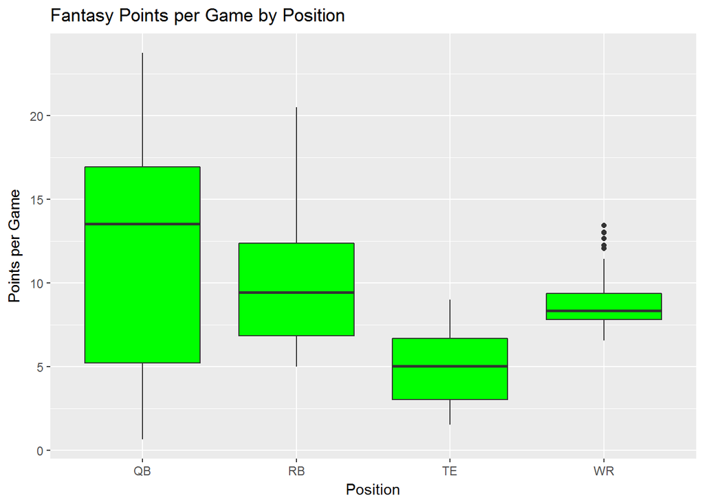

```r
ggplot(fantasy, aes(x=fantasy$Position, y=fantasy$Fantasy_PPG)) +
  geom_boxplot(fill="green") +
  labs(title="Fantasy Points per Game by Position", x="Position", y="Points per Game")
```

#### Create violin plots to show the distribution of points by position

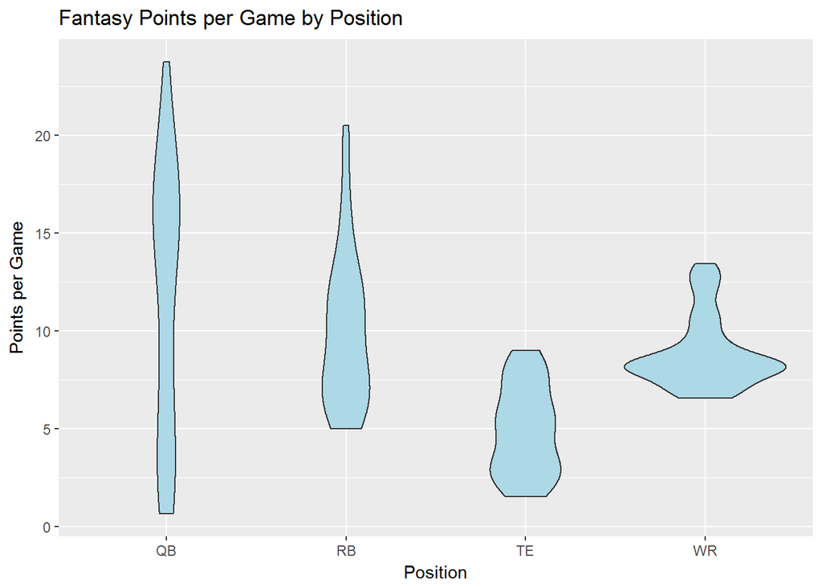

```r
ggplot(fantasy, aes(x=fantasy$Position, y=fantasy$Fantasy_PPG)) +
  geom_violin(fill="light blue") +
  labs(title="Fantasy Points per Game by Position", x="Position", y="Points per Game")
```

#### Create violin and box plots to show the distribution of points by position

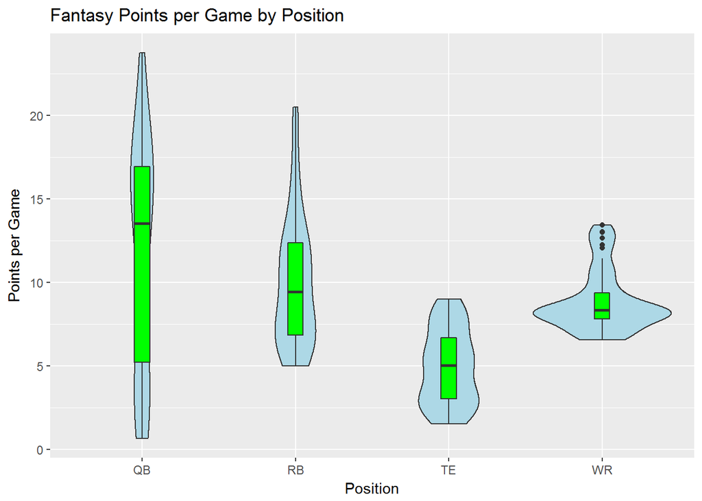

```r
ggplot(fantasy, aes(x=fantasy$Position, y=fantasy$Fantasy_PPG)) +
  geom_violin(fill="light blue") +
  geom_boxplot(fill="green", width=.1) +
  labs(title="Fantasy Points per Game by Position", x="Position", y="Points per Game")
```

### Task 3

#### Scatter plots

##### Quarterbacks

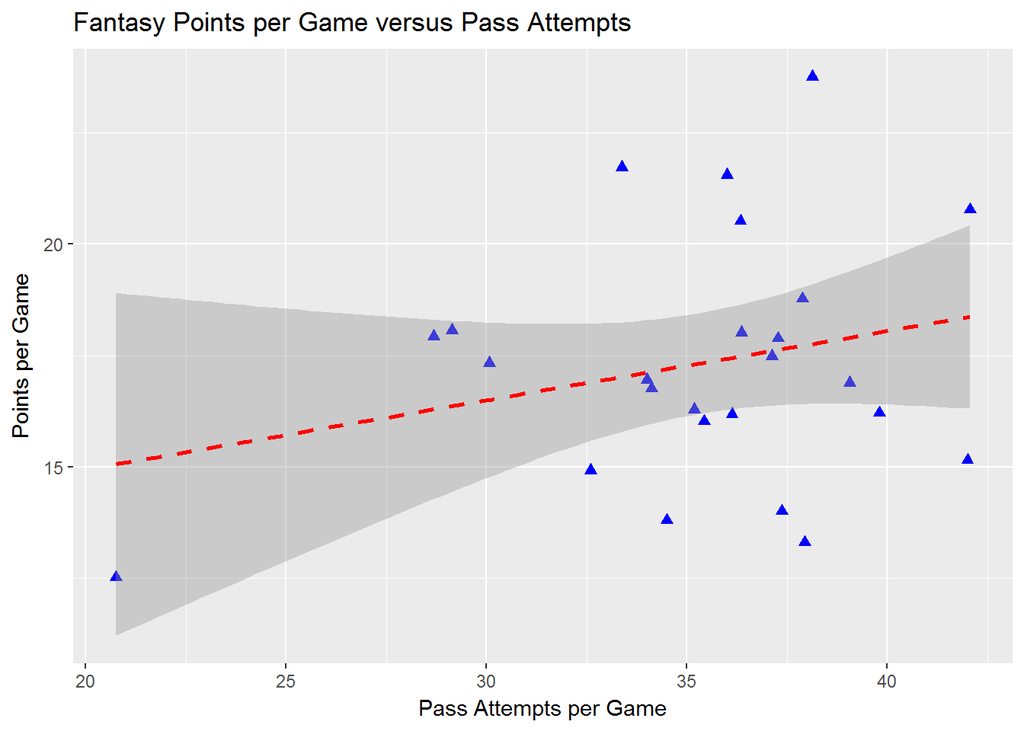

```r
ggplot(qb, aes(x=qb$Pass_Attempts_Per_Game, y=qb$Fantasy_PPG)) +
  geom_point(pch=17, color="blue", size=2) +
  geom_smooth(method="lm", color="red", linetype=2) +
  labs(title="Fantasy Points per Game versus Pass Attempts", x="Pass Attempts per Game", y="Points per Game")
```

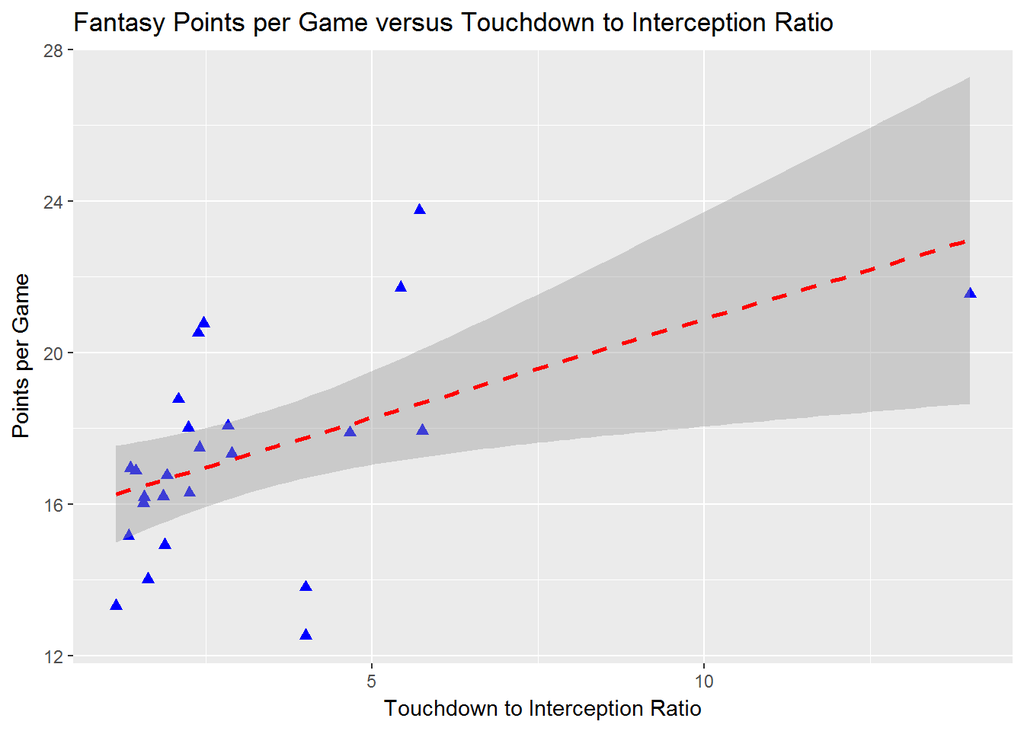

```r
ggplot(qb, aes(x=qb$Pass_TD_Int_Ratio, y=qb$Fantasy_PPG)) +
  geom_point(pch=17, color="blue", size=2) +
  geom_smooth(method="lm", color="red", linetype=2) +
  labs(title="Fantasy Points per Game versus Touchdown to Interception Ratio", x="Touchdown to Interception Ratio", y="Points per Game")
```

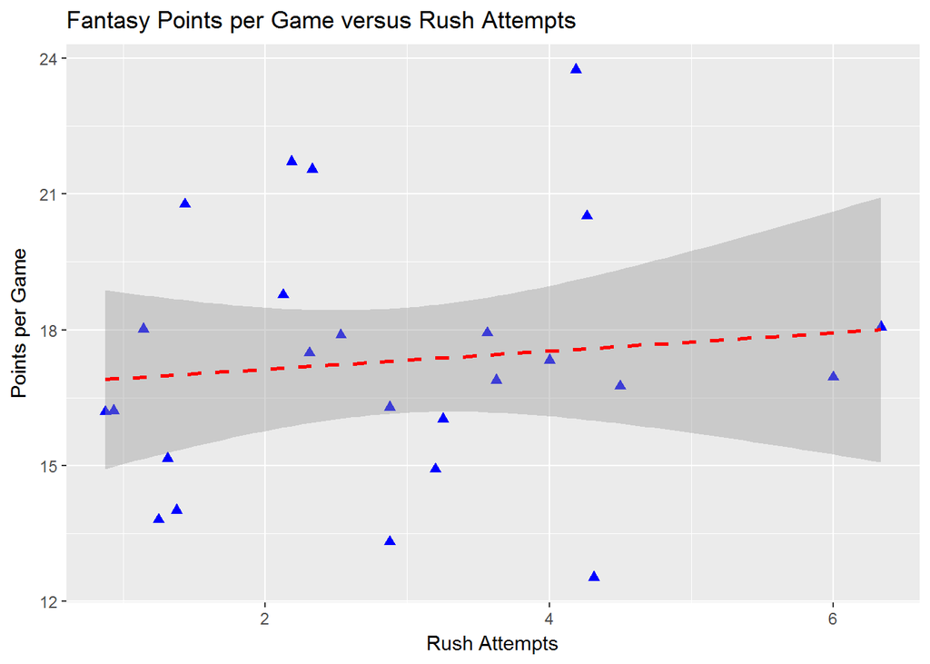

```r
ggplot(qb, aes(x=qb$Rush_Attempts_Per_Game, y=qb$Fantasy_PPG)) +
  geom_point(pch=17, color="blue", size=2) +
  geom_smooth(method="lm", color="red", linetype=2) +
  labs(title="Fantasy Points per Game versus Rush Attempts", x="Rush Attempts", y="Points per Game")
```

##### Running Backs

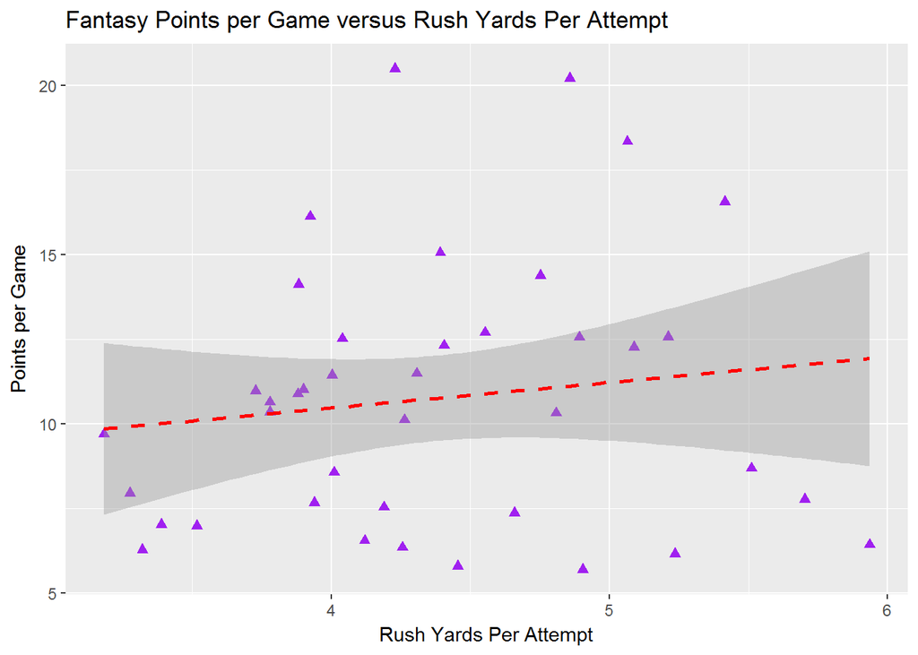

```r
ggplot(rb, aes(x=rb$Rush_Yards_Per_Attempt, y=rb$Fantasy_PPG)) +
  geom_point(pch=17, color="purple", size=2) +
  geom_smooth(method="lm", color="red", linetype=2) +
  labs(title="Fantasy Points per Game versus Rush Yards Per Attempt", x="Rush Yards Per Attempt", y="Points per Game")
```

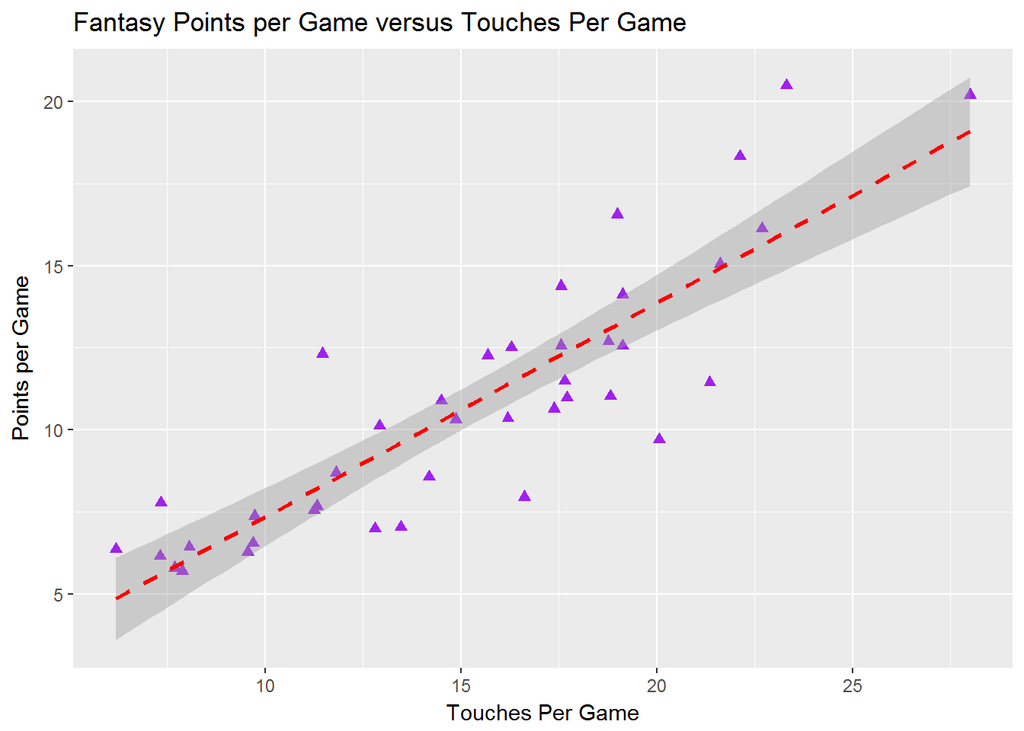

```r
ggplot(rb, aes(x=rb$Touches_Per_Game, y=rb$Fantasy_PPG)) +
  geom_point(pch=17, color="purple", size=2) +
  geom_smooth(method="lm", color="red", linetype=2) +
  labs(title="Fantasy Points per Game versus Touches Per Game", x="Touches Per Game", y="Points per Game")
```

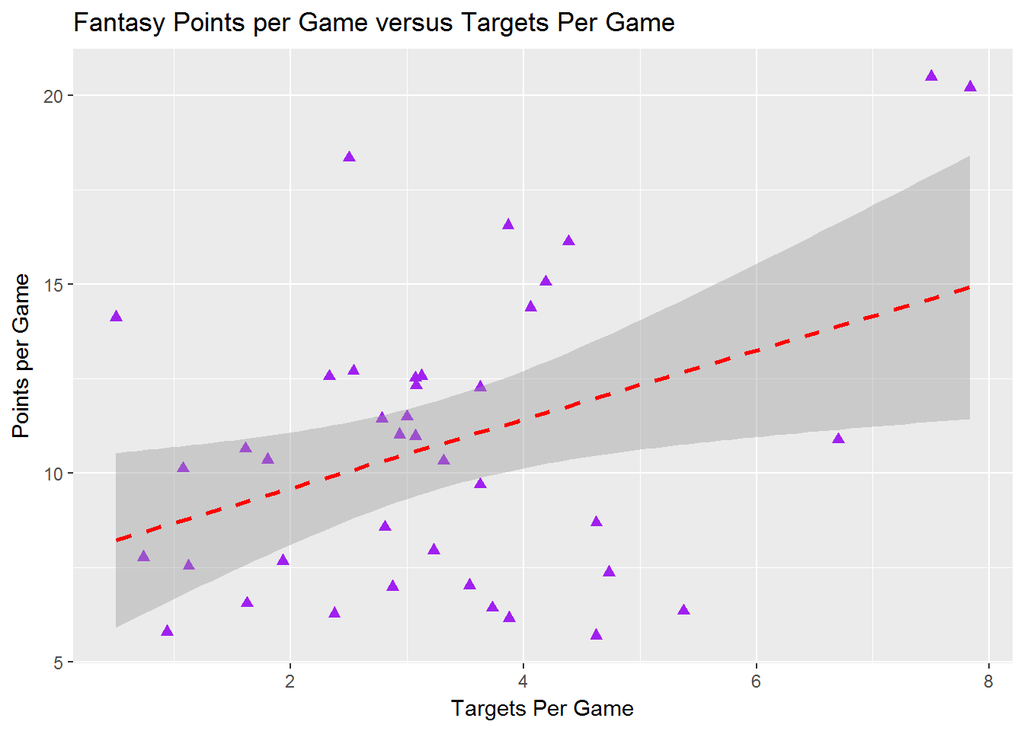

```r
ggplot(rb, aes(x=rb$Targets_Per_Game, y=rb$Fantasy_PPG)) +
  geom_point(pch=17, color="purple", size=2) +
  geom_smooth(method="lm", color="red", linetype=2) +
  labs(title="Fantasy Points per Game versus Targets Per Game", x="Targets Per Game", y="Points per Game")
```

##### Wide Receivers

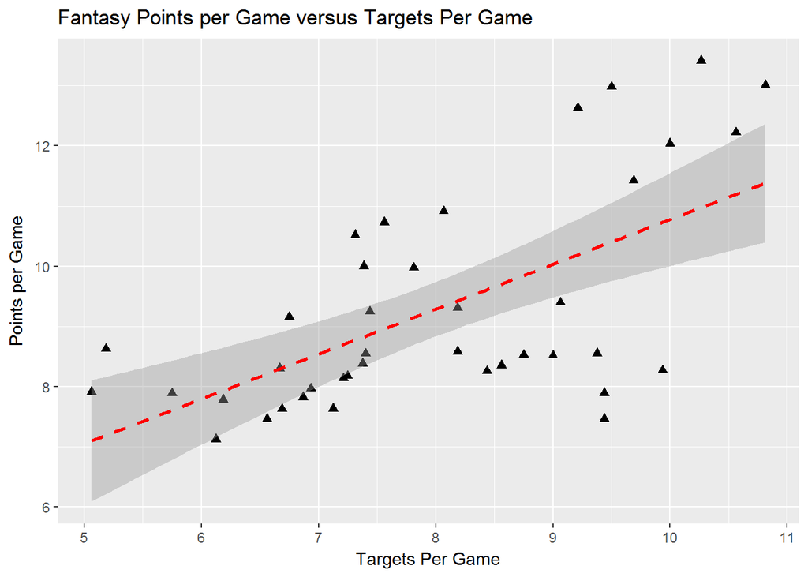

```r
ggplot(wr, aes(x=wr$Targets_Per_Game, y=wr$Fantasy_PPG)) +
  geom_point(pch=17, color="black", size=2) +
  geom_smooth(method="lm", color="red", linetype=2) +
  labs(title="Fantasy Points per Game versus Targets Per Game", x="Targets Per Game", y="Points per Game")
```

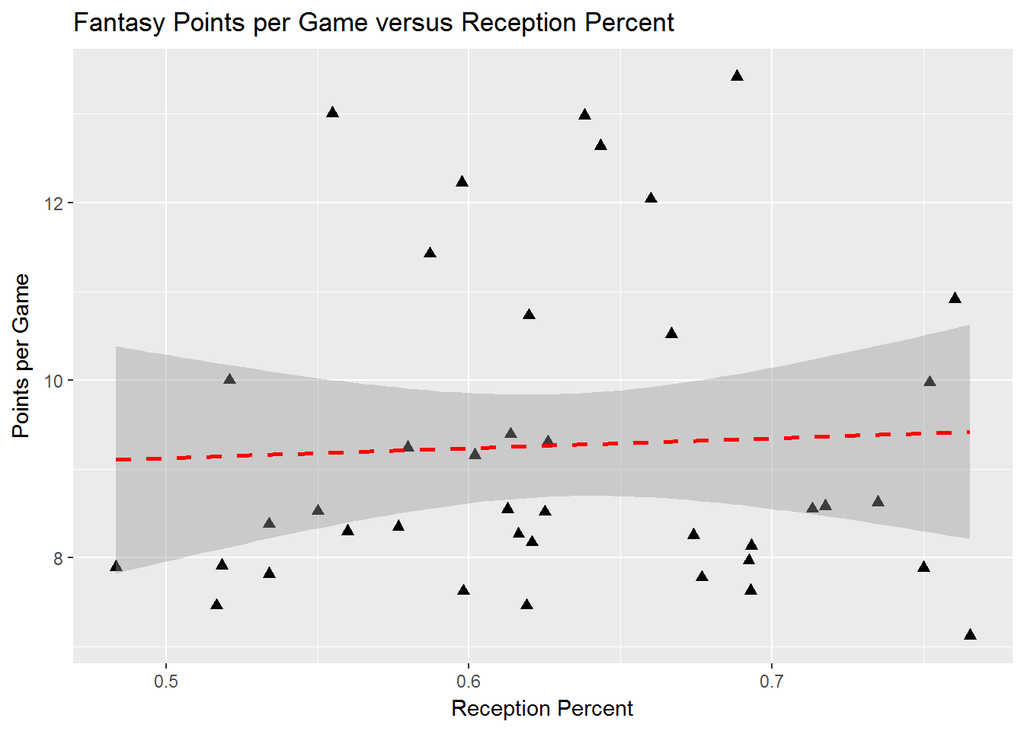

```r
ggplot(wr, aes(x=wr$Reception_Percent, y=wr$Fantasy_PPG)) +
  geom_point(pch=17, color="black", size=2) +
  geom_smooth(method="lm", color="red", linetype=2) +
  labs(title="Fantasy Points per Game versus Reception Percent", x="Reception Percent", y="Points per Game")
```

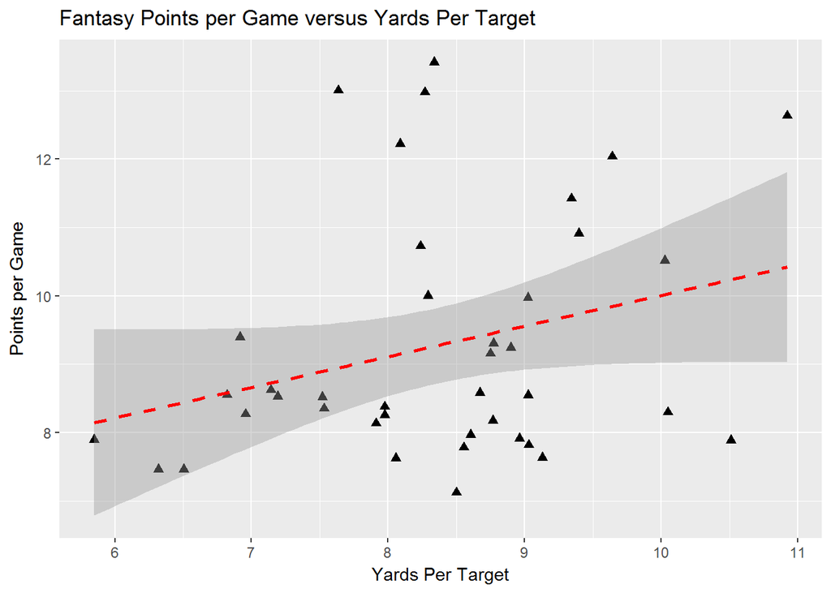

```r
ggplot(wr, aes(x=wr$Yards_Per_Target, y=wr$Fantasy_PPG)) +
  geom_point(pch=17, color="black", size=2) +
  geom_smooth(method="lm", color="red", linetype=2) +
  labs(title="Fantasy Points per Game versus Yards Per Target", x="Yards Per Target", y="Points per Game")
```

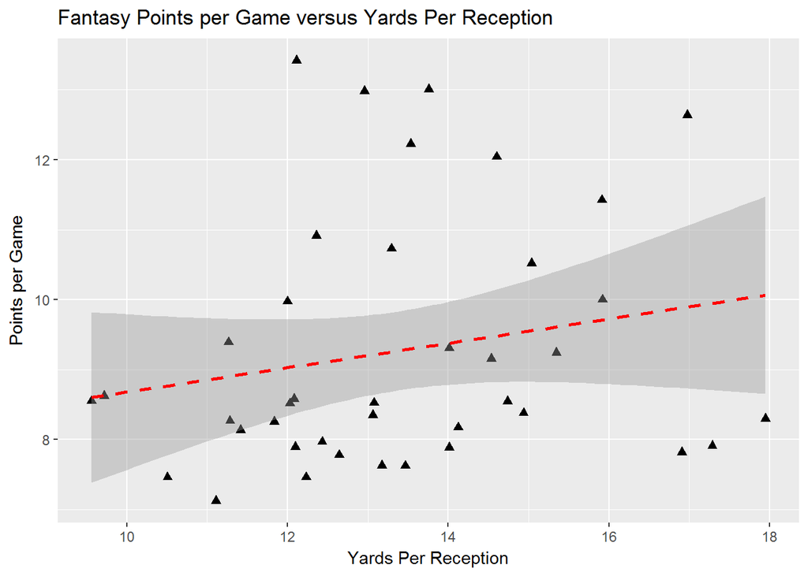

```r
ggplot(wr, aes(x=wr$Yards_Per_Reception, y=wr$Fantasy_PPG)) +
  geom_point(pch=17, color="black", size=2) +
  geom_smooth(method="lm", color="red", linetype=2) +
  labs(title="Fantasy Points per Game versus Yards Per Reception", x="Yards Per Reception", y="Points per Game")
```

##### Tight Ends

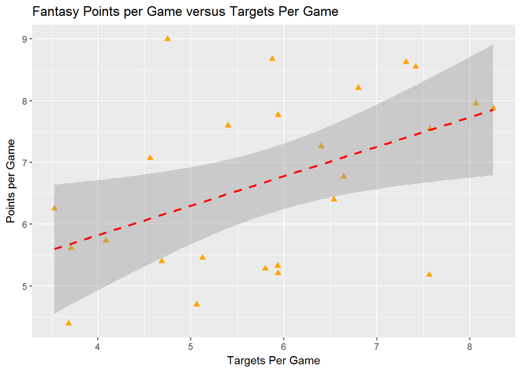

```r
ggplot(te, aes(x=te$Targets_Per_Game, y=te$Fantasy_PPG)) +
  geom_point(pch=17, color="orange", size=2) +
  geom_smooth(method="lm", color="red", linetype=2) +
  labs(title="Fantasy Points per Game versus Targets Per Game", x="Targets Per Game", y="Points per Game")
```

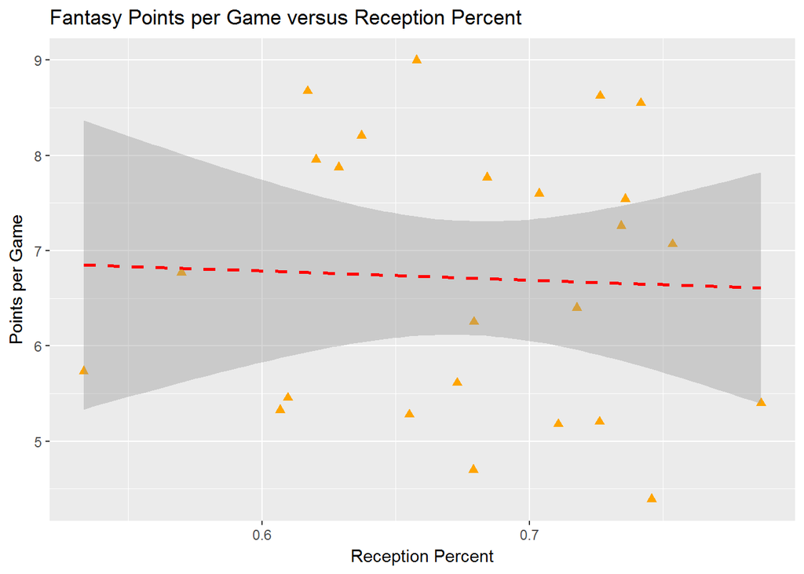

```r
ggplot(te, aes(x=te$Reception_Percent, y=te$Fantasy_PPG)) +
  geom_point(pch=17, color="orange", size=2) +
  geom_smooth(method="lm", color="red", linetype=2) +
  labs(title="Fantasy Points per Game versus Reception Percent", x="Reception Percent", y="Points per Game")
```

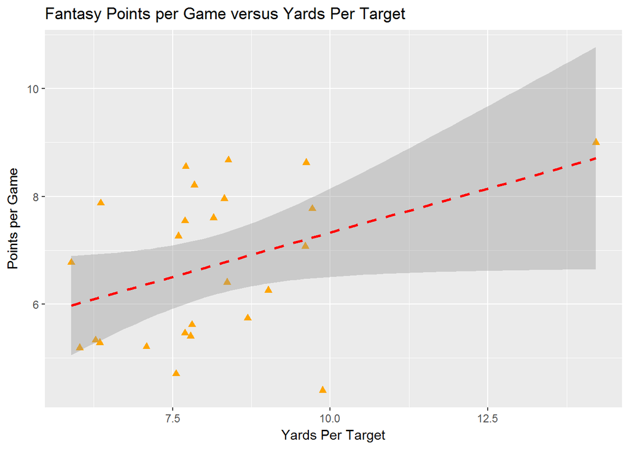

```r
ggplot(te, aes(x=te$Yards_Per_Target, y=te$Fantasy_PPG)) +
  geom_point(pch=17, color="orange", size=2) +
  geom_smooth(method="lm", color="red", linetype=2) +
  labs(title="Fantasy Points per Game versus Yards Per Target", x="Yards Per Target", y="Points per Game")
```

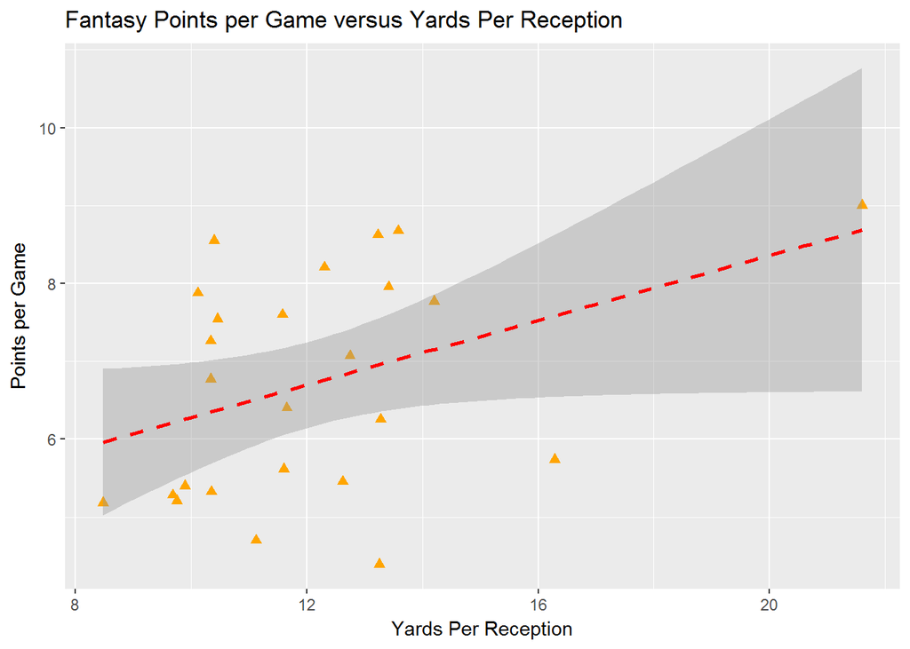

```r
ggplot(te, aes(x=te$Yards_Per_Reception, y=te$Fantasy_PPG)) +
  geom_point(pch=17, color="orange", size=2) +
  geom_smooth(method="lm", color="red", linetype=2) +
  labs(title="Fantasy Points per Game versus Yards Per Reception", x="Yards Per Reception", y="Points per Game")
```

#### Correlations

##### Quarterbacks

```r
cor(qb[,-1])
```

```
##                        Pass_Attempts_Per_Game Pass_Yards_Per_Game
## Pass_Attempts_Per_Game                  1.000               0.781
## Pass_Yards_Per_Game                     0.781               1.000
## Pass_TD_Per_Game                        0.369               0.688
## Pass_TD_Int_Ratio                      -0.176               0.143
## Rush_Yards_Per_Game                    -0.604              -0.617
## Rush_Attempts_Per_Game                 -0.537              -0.534
## Fantasy_PPG                             0.255               0.626
##                        Pass_TD_Per_Game Pass_TD_Int_Ratio
## Pass_Attempts_Per_Game            0.369          -0.17555
## Pass_Yards_Per_Game               0.688           0.14337
## Pass_TD_Per_Game                  1.000           0.44304
## Pass_TD_Int_Ratio                 0.443           1.00000
## Rush_Yards_Per_Game              -0.295          -0.01625
## Rush_Attempts_Per_Game           -0.313          -0.00777
## Fantasy_PPG                       0.800           0.50298
##                        Rush_Yards_Per_Game Rush_Attempts_Per_Game
## Pass_Attempts_Per_Game             -0.6039               -0.53677
## Pass_Yards_Per_Game                -0.6173               -0.53380
## Pass_TD_Per_Game                   -0.2946               -0.31254
## Pass_TD_Int_Ratio                  -0.0163               -0.00777
## Rush_Yards_Per_Game                 1.0000                0.92078
## Rush_Attempts_Per_Game              0.9208                1.00000
## Fantasy_PPG                         0.0886                0.10983
##                        Fantasy_PPG
## Pass_Attempts_Per_Game      0.2554
## Pass_Yards_Per_Game         0.6256
## Pass_TD_Per_Game            0.8004
## Pass_TD_Int_Ratio           0.5030
## Rush_Yards_Per_Game         0.0886
## Rush_Attempts_Per_Game      0.1098
## Fantasy_PPG                 1.0000
```

```r
cor(qb[,-1], method="spearman")
```

```
##                        Pass_Attempts_Per_Game Pass_Yards_Per_Game
## Pass_Attempts_Per_Game                 1.0000               0.580
## Pass_Yards_Per_Game                    0.5800               1.000
## Pass_TD_Per_Game                       0.3204               0.724
## Pass_TD_Int_Ratio                     -0.3747               0.100
## Rush_Yards_Per_Game                   -0.5185              -0.507
## Rush_Attempts_Per_Game                -0.5039              -0.509
## Fantasy_PPG                            0.0869               0.565
##                        Pass_TD_Per_Game Pass_TD_Int_Ratio
## Pass_Attempts_Per_Game            0.320            -0.375
## Pass_Yards_Per_Game               0.724             0.100
## Pass_TD_Per_Game                  1.000             0.371
## Pass_TD_Int_Ratio                 0.371             1.000
## Rush_Yards_Per_Game              -0.320             0.168
## Rush_Attempts_Per_Game           -0.288             0.134
## Fantasy_PPG                       0.705             0.559
##                        Rush_Yards_Per_Game Rush_Attempts_Per_Game
## Pass_Attempts_Per_Game              -0.518                 -0.504
## Pass_Yards_Per_Game                 -0.507                 -0.509
## Pass_TD_Per_Game                    -0.320                 -0.288
## Pass_TD_Int_Ratio                    0.168                  0.134
## Rush_Yards_Per_Game                  1.000                  0.922
## Rush_Attempts_Per_Game               0.922                  1.000
## Fantasy_PPG                          0.125                  0.130
##                        Fantasy_PPG
## Pass_Attempts_Per_Game      0.0869
## Pass_Yards_Per_Game         0.5646
## Pass_TD_Per_Game            0.7052
## Pass_TD_Int_Ratio           0.5586
## Rush_Yards_Per_Game         0.1254
## Rush_Attempts_Per_Game      0.1300
## Fantasy_PPG                 1.0000
```

```r
cor(qb[,-1], method="kendall")
```

```
##                        Pass_Attempts_Per_Game Pass_Yards_Per_Game
## Pass_Attempts_Per_Game                 1.0000              0.4200
## Pass_Yards_Per_Game                    0.4200              1.0000
## Pass_TD_Per_Game                       0.2088              0.5522
## Pass_TD_Int_Ratio                     -0.2437              0.0968
## Rush_Yards_Per_Game                   -0.3867             -0.3400
## Rush_Attempts_Per_Game                -0.3506             -0.3907
## Fantasy_PPG                            0.0333              0.4000
##                        Pass_TD_Per_Game Pass_TD_Int_Ratio
## Pass_Attempts_Per_Game            0.209           -0.2437
## Pass_Yards_Per_Game               0.552            0.0968
## Pass_TD_Per_Game                  1.000            0.2867
## Pass_TD_Int_Ratio                 0.287            1.0000
## Rush_Yards_Per_Game              -0.215            0.1235
## Rush_Attempts_Per_Game           -0.206            0.0870
## Fantasy_PPG                       0.572            0.4174
##                        Rush_Yards_Per_Game Rush_Attempts_Per_Game
## Pass_Attempts_Per_Game              -0.387                -0.3506
## Pass_Yards_Per_Game                 -0.340                -0.3907
## Pass_TD_Per_Game                    -0.215                -0.2057
## Pass_TD_Int_Ratio                    0.124                 0.0870
## Rush_Yards_Per_Game                  1.000                 0.7646
## Rush_Attempts_Per_Game               0.765                 1.0000
## Fantasy_PPG                          0.127                 0.0902
##                        Fantasy_PPG
## Pass_Attempts_Per_Game      0.0333
## Pass_Yards_Per_Game         0.4000
## Pass_TD_Per_Game            0.5724
## Pass_TD_Int_Ratio           0.4174
## Rush_Yards_Per_Game         0.1267
## Rush_Attempts_Per_Game      0.0902
## Fantasy_PPG                 1.0000
```

##### Running Backs

```r
cor(rb[,-1])
```

```
##                        Rush_Yards_Per_Game Rush_Attempts_Per_Game
## Rush_Yards_Per_Game                 1.0000                 0.9293
## Rush_Attempts_Per_Game              0.9293                 1.0000
## Rush_Yards_Per_Attempt              0.1326                -0.2160
## Rush_TD_Per_Game                    0.6607                 0.6489
## Touches_Per_Game                    0.9205                 0.9709
## Targets_Per_Game                    0.1199                 0.0612
## Reception_Percent                  -0.0275                -0.0840
## Fantasy_PPG                         0.8895                 0.8152
##                        Rush_Yards_Per_Attempt Rush_TD_Per_Game
## Rush_Yards_Per_Game                    0.1326           0.6607
## Rush_Attempts_Per_Game                -0.2160           0.6489
## Rush_Yards_Per_Attempt                 1.0000           0.0193
## Rush_TD_Per_Game                       0.0193           1.0000
## Touches_Per_Game                      -0.1703           0.5836
## Targets_Per_Game                       0.1275          -0.1451
## Reception_Percent                      0.1121           0.0273
## Fantasy_PPG                            0.1322           0.7497
##                        Touches_Per_Game Targets_Per_Game Reception_Percent
## Rush_Yards_Per_Game              0.9205           0.1199         -0.027483
## Rush_Attempts_Per_Game           0.9709           0.0612         -0.084008
## Rush_Yards_Per_Attempt          -0.1703           0.1275          0.112091
## Rush_TD_Per_Game                 0.5836          -0.1451          0.027348
## Touches_Per_Game                 1.0000           0.2940         -0.070485
## Targets_Per_Game                 0.2940           1.0000         -0.120046
## Reception_Percent               -0.0705          -0.1200          1.000000
## Fantasy_PPG                      0.8723           0.3850         -0.000481
##                        Fantasy_PPG
## Rush_Yards_Per_Game       0.889497
## Rush_Attempts_Per_Game    0.815182
## Rush_Yards_Per_Attempt    0.132224
## Rush_TD_Per_Game          0.749719
## Touches_Per_Game          0.872264
## Targets_Per_Game          0.385007
## Reception_Percent        -0.000481
## Fantasy_PPG               1.000000
```

```r
cor(rb[,-1], method="spearman")
```

```
##                        Rush_Yards_Per_Game Rush_Attempts_Per_Game
## Rush_Yards_Per_Game                1.00000                0.92153
## Rush_Attempts_Per_Game             0.92153                1.00000
## Rush_Yards_Per_Attempt             0.12871               -0.19851
## Rush_TD_Per_Game                   0.68095                0.64622
## Touches_Per_Game                   0.91477                0.97382
## Targets_Per_Game                   0.00328               -0.04222
## Reception_Percent                  0.04692                0.00385
## Fantasy_PPG                        0.92383                0.84160
##                        Rush_Yards_Per_Attempt Rush_TD_Per_Game
## Rush_Yards_Per_Game                   0.12871          0.68095
## Rush_Attempts_Per_Game               -0.19851          0.64622
## Rush_Yards_Per_Attempt                1.00000          0.00733
## Rush_TD_Per_Game                      0.00733          1.00000
## Touches_Per_Game                     -0.15939          0.58112
## Targets_Per_Game                      0.22208         -0.27814
## Reception_Percent                     0.09383          0.09701
## Fantasy_PPG                           0.12533          0.72669
##                        Touches_Per_Game Targets_Per_Game Reception_Percent
## Rush_Yards_Per_Game             0.91477          0.00328           0.04692
## Rush_Attempts_Per_Game          0.97382         -0.04222           0.00385
## Rush_Yards_Per_Attempt         -0.15939          0.22208           0.09383
## Rush_TD_Per_Game                0.58112         -0.27814           0.09701
## Touches_Per_Game                1.00000          0.13595           0.00638
## Targets_Per_Game                0.13595          1.00000          -0.26806
## Reception_Percent               0.00638         -0.26806           1.00000
## Fantasy_PPG                     0.87481          0.16015           0.05752
##                        Fantasy_PPG
## Rush_Yards_Per_Game         0.9238
## Rush_Attempts_Per_Game      0.8416
## Rush_Yards_Per_Attempt      0.1253
## Rush_TD_Per_Game            0.7267
## Touches_Per_Game            0.8748
## Targets_Per_Game            0.1602
## Reception_Percent           0.0575
## Fantasy_PPG                 1.0000
```

```r
cor(rb[,-1], method="kendall")
```

```
##                        Rush_Yards_Per_Game Rush_Attempts_Per_Game
## Rush_Yards_Per_Game                1.00000                0.76588
## Rush_Attempts_Per_Game             0.76588                1.00000
## Rush_Yards_Per_Attempt             0.10513               -0.12957
## Rush_TD_Per_Game                   0.50068                0.47375
## Touches_Per_Game                   0.75561                0.87291
## Targets_Per_Game                   0.00128               -0.02314
## Reception_Percent                  0.02701               -0.00257
## Fantasy_PPG                        0.78205                0.65811
##                        Rush_Yards_Per_Attempt Rush_TD_Per_Game
## Rush_Yards_Per_Game                   0.10513          0.50068
## Rush_Attempts_Per_Game               -0.12957          0.47375
## Rush_Yards_Per_Attempt                1.00000          0.00519
## Rush_TD_Per_Game                      0.00519          1.00000
## Touches_Per_Game                     -0.09878          0.42183
## Targets_Per_Game                      0.11946         -0.23913
## Reception_Percent                     0.06302          0.07938
## Fantasy_PPG                           0.10769          0.54997
##                        Touches_Per_Game Targets_Per_Game Reception_Percent
## Rush_Yards_Per_Game             0.75561          0.00128           0.02701
## Rush_Attempts_Per_Game          0.87291         -0.02314          -0.00257
## Rush_Yards_Per_Attempt         -0.09878          0.11946           0.06302
## Rush_TD_Per_Game                0.42183         -0.23913           0.07938
## Touches_Per_Game                1.00000          0.09512           0.00515
## Targets_Per_Game                0.09512          1.00000          -0.20361
## Reception_Percent               0.00515         -0.20361           1.00000
## Fantasy_PPG                     0.71456          0.11432           0.03987
##                        Fantasy_PPG
## Rush_Yards_Per_Game         0.7821
## Rush_Attempts_Per_Game      0.6581
## Rush_Yards_Per_Attempt      0.1077
## Rush_TD_Per_Game            0.5500
## Touches_Per_Game            0.7146
## Targets_Per_Game            0.1143
## Reception_Percent           0.0399
## Fantasy_PPG                 1.0000
```

##### Wide Receivers

```r
cor(wr[,-1])
```

```
##                       Targets_Per_Game Reception_Percent
## Targets_Per_Game                 1.000           -0.1913
## Reception_Percent               -0.191            1.0000
## Reception_TD_Per_Game            0.229           -0.0625
## Yards_Per_Target                -0.268            0.3047
## Yards_Per_Reception             -0.140           -0.5014
## Fantasy_PPG                      0.621            0.0469
##                       Reception_TD_Per_Game Yards_Per_Target
## Targets_Per_Game                     0.2287          -0.2680
## Reception_Percent                   -0.0625           0.3047
## Reception_TD_Per_Game                1.0000           0.0154
## Yards_Per_Target                     0.0154           1.0000
## Yards_Per_Reception                  0.0641           0.6643
## Fantasy_PPG                          0.7247           0.2846
##                       Yards_Per_Reception Fantasy_PPG
## Targets_Per_Game                  -0.1397      0.6206
## Reception_Percent                 -0.5014      0.0469
## Reception_TD_Per_Game              0.0641      0.7247
## Yards_Per_Target                   0.6643      0.2846
## Yards_Per_Reception                1.0000      0.1979
## Fantasy_PPG                        0.1979      1.0000
```

```r
cor(wr[,-1], method="spearman")
```

```
##                       Targets_Per_Game Reception_Percent
## Targets_Per_Game                 1.000           -0.1774
## Reception_Percent               -0.177            1.0000
## Reception_TD_Per_Game            0.142           -0.0747
## Yards_Per_Target                -0.264            0.2512
## Yards_Per_Reception             -0.120           -0.4964
## Fantasy_PPG                      0.602            0.0592
##                       Reception_TD_Per_Game Yards_Per_Target
## Targets_Per_Game                     0.1418          -0.2636
## Reception_Percent                   -0.0747           0.2512
## Reception_TD_Per_Game                1.0000           0.0173
## Yards_Per_Target                     0.0173           1.0000
## Yards_Per_Reception                  0.1448           0.6681
## Fantasy_PPG                          0.6035           0.2123
##                       Yards_Per_Reception Fantasy_PPG
## Targets_Per_Game                   -0.120      0.6017
## Reception_Percent                  -0.496      0.0592
## Reception_TD_Per_Game               0.145      0.6035
## Yards_Per_Target                    0.668      0.2123
## Yards_Per_Reception                 1.000      0.2140
## Fantasy_PPG                         0.214      1.0000
```

```r
cor(wr[,-1], method="kendall")
```

```
##                       Targets_Per_Game Reception_Percent
## Targets_Per_Game                1.0000           -0.1130
## Reception_Percent              -0.1130            1.0000
## Reception_TD_Per_Game           0.0833           -0.0409
## Yards_Per_Target               -0.1951            0.1718
## Yards_Per_Reception            -0.0873           -0.3513
## Fantasy_PPG                     0.4509            0.0526
##                       Reception_TD_Per_Game Yards_Per_Target
## Targets_Per_Game                     0.0833          -0.1951
## Reception_Percent                   -0.0409           0.1718
## Reception_TD_Per_Game                1.0000           0.0066
## Yards_Per_Target                     0.0066           1.0000
## Yards_Per_Reception                  0.0885           0.4769
## Fantasy_PPG                          0.4546           0.1424
##                       Yards_Per_Reception Fantasy_PPG
## Targets_Per_Game                  -0.0873      0.4509
## Reception_Percent                 -0.3513      0.0526
## Reception_TD_Per_Game              0.0885      0.4546
## Yards_Per_Target                   0.4769      0.1424
## Yards_Per_Reception                1.0000      0.1398
## Fantasy_PPG                        0.1398      1.0000
```

##### Tight Ends

```r
cor(te[,-1])
```

```
##                       Targets_Per_Game Reception_Percent
## Targets_Per_Game                1.0000           -0.0171
## Reception_Percent              -0.0171            1.0000
## Reception_TD_Per_Game          -0.0987           -0.2040
## Yards_Per_Target               -0.3923            0.1544
## Yards_Per_Reception            -0.3805           -0.2849
## Fantasy_PPG                     0.4712           -0.0427
##                       Reception_TD_Per_Game Yards_Per_Target
## Targets_Per_Game                    -0.0987           -0.392
## Reception_Percent                   -0.2040            0.154
## Reception_TD_Per_Game                1.0000            0.077
## Yards_Per_Target                     0.0770            1.000
## Yards_Per_Reception                  0.1576            0.900
## Fantasy_PPG                          0.5633            0.397
##                       Yards_Per_Reception Fantasy_PPG
## Targets_Per_Game                   -0.381      0.4712
## Reception_Percent                  -0.285     -0.0427
## Reception_TD_Per_Game               0.158      0.5633
## Yards_Per_Target                    0.900      0.3967
## Yards_Per_Reception                 1.000      0.3913
## Fantasy_PPG                         0.391      1.0000
```

```r
cor(te[,-1], method="spearman")
```

```
##                       Targets_Per_Game Reception_Percent
## Targets_Per_Game                1.0000           -0.0400
## Reception_Percent              -0.0400            1.0000
## Reception_TD_Per_Game          -0.0858           -0.1461
## Yards_Per_Target               -0.4066            0.2377
## Yards_Per_Reception            -0.3508           -0.2015
## Fantasy_PPG                     0.4062           -0.0885
##                       Reception_TD_Per_Game Yards_Per_Target
## Targets_Per_Game                    -0.0858           -0.407
## Reception_Percent                   -0.1461            0.238
## Reception_TD_Per_Game                1.0000            0.121
## Yards_Per_Target                     0.1211            1.000
## Yards_Per_Reception                  0.1477            0.869
## Fantasy_PPG                          0.5653            0.414
##                       Yards_Per_Reception Fantasy_PPG
## Targets_Per_Game                   -0.351      0.4062
## Reception_Percent                  -0.202     -0.0885
## Reception_TD_Per_Game               0.148      0.5653
## Yards_Per_Target                    0.869      0.4138
## Yards_Per_Reception                 1.000      0.4492
## Fantasy_PPG                         0.449      1.0000
```

```r
cor(te[,-1], method="kendall")
```

```
##                       Targets_Per_Game Reception_Percent
## Targets_Per_Game                1.0000           -0.0100
## Reception_Percent              -0.0100            1.0000
## Reception_TD_Per_Game          -0.0612           -0.0917
## Yards_Per_Target               -0.2838            0.1733
## Yards_Per_Reception            -0.2437           -0.1467
## Fantasy_PPG                     0.2638           -0.0667
##                       Reception_TD_Per_Game Yards_Per_Target
## Targets_Per_Game                    -0.0612           -0.284
## Reception_Percent                   -0.0917            0.173
## Reception_TD_Per_Game                1.0000            0.105
## Yards_Per_Target                     0.1053            1.000
## Yards_Per_Reception                  0.1121            0.680
## Fantasy_PPG                          0.4313            0.320
##                       Yards_Per_Reception Fantasy_PPG
## Targets_Per_Game                   -0.244      0.2638
## Reception_Percent                  -0.147     -0.0667
## Reception_TD_Per_Game               0.112      0.4313
## Yards_Per_Target                    0.680      0.3200
## Yards_Per_Reception                 1.000      0.3333
## Fantasy_PPG                         0.333      1.0000
```

#### Corrgrams

##### Quarterbacks

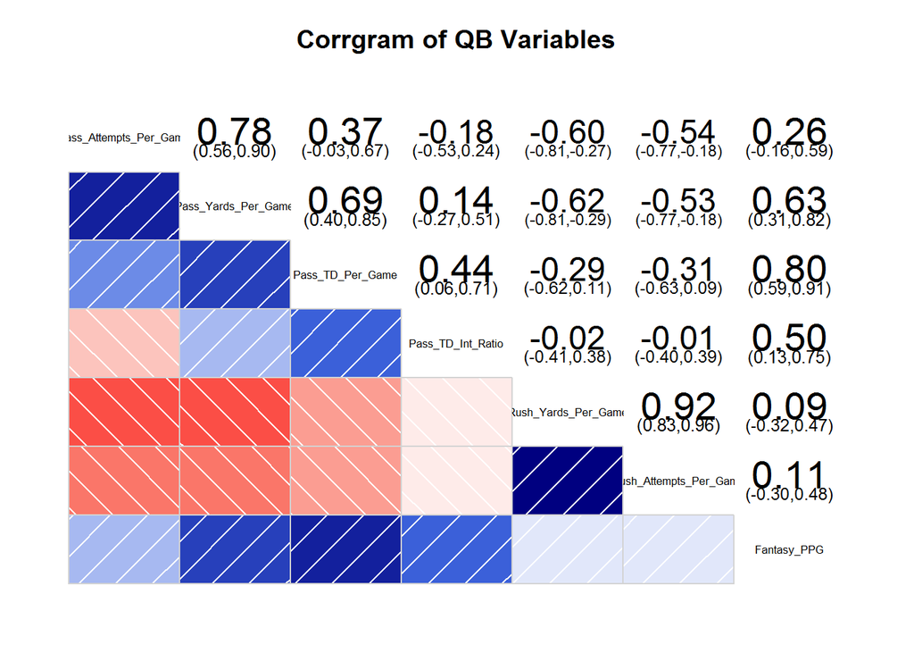

```r
corrgram(qb[,-1],lower.panel=panel.shade, upper.panel=panel.conf,main="Corrgram of QB Variables")
```

##### Running Backs

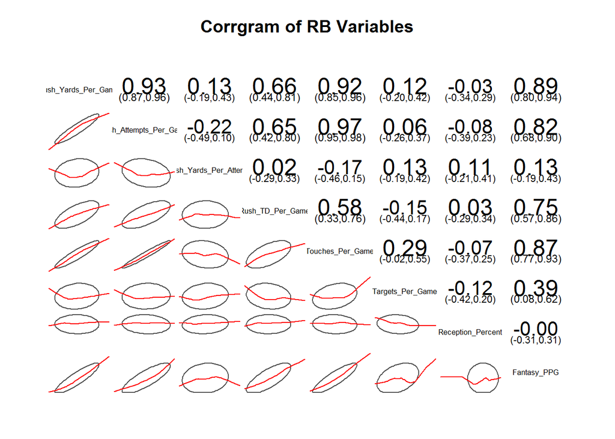

```r
corrgram(rb[,-1],lower.panel=panel.ellipse, upper.panel=panel.conf,main="Corrgram of RB Variables")
```

##### Wide Receivers

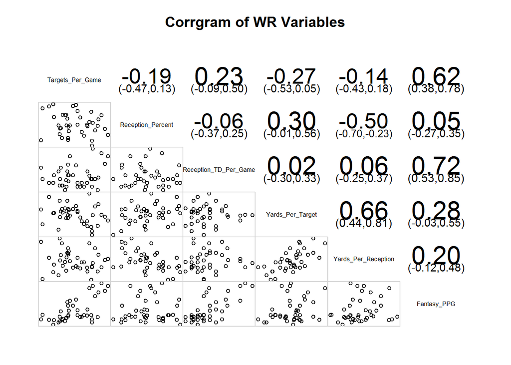

```r
corrgram(wr[,-1],lower.panel=panel.pts, upper.panel=panel.conf,main="Corrgram of WR Variables")
```

##### Tight Ends

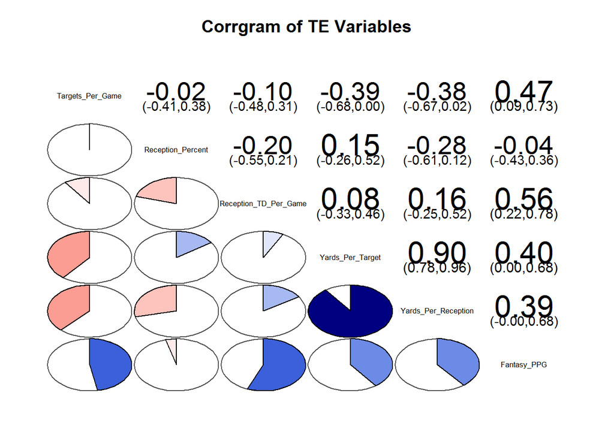

```r
corrgram(te[,-1],lower.panel=panel.pie, upper.panel=panel.conf,main="Corrgram of TE Variables")
```

#### Correlation Test for Significance

##### Quarterbacks

```r
corr.test(qb[,-1])
```

```
## Call:corr.test(x = qb[, -1])
## Correlation matrix
##                        Pass_Attempts_Per_Game Pass_Yards_Per_Game
## Pass_Attempts_Per_Game                   1.00                0.78
## Pass_Yards_Per_Game                      0.78                1.00
## Pass_TD_Per_Game                         0.37                0.69
## Pass_TD_Int_Ratio                       -0.18                0.14
## Rush_Yards_Per_Game                     -0.60               -0.62
## Rush_Attempts_Per_Game                  -0.54               -0.53
## Fantasy_PPG                              0.26                0.63
##                        Pass_TD_Per_Game Pass_TD_Int_Ratio
## Pass_Attempts_Per_Game             0.37             -0.18
## Pass_Yards_Per_Game                0.69              0.14
## Pass_TD_Per_Game                   1.00              0.44
## Pass_TD_Int_Ratio                  0.44              1.00
## Rush_Yards_Per_Game               -0.29             -0.02
## Rush_Attempts_Per_Game            -0.31             -0.01
## Fantasy_PPG                        0.80              0.50
##                        Rush_Yards_Per_Game Rush_Attempts_Per_Game
## Pass_Attempts_Per_Game               -0.60                  -0.54
## Pass_Yards_Per_Game                  -0.62                  -0.53
## Pass_TD_Per_Game                     -0.29                  -0.31
## Pass_TD_Int_Ratio                    -0.02                  -0.01
## Rush_Yards_Per_Game                   1.00                   0.92
## Rush_Attempts_Per_Game                0.92                   1.00
## Fantasy_PPG                           0.09                   0.11
##                        Fantasy_PPG
## Pass_Attempts_Per_Game        0.26
## Pass_Yards_Per_Game           0.63
## Pass_TD_Per_Game              0.80
## Pass_TD_Int_Ratio             0.50
## Rush_Yards_Per_Game           0.09
## Rush_Attempts_Per_Game        0.11
## Fantasy_PPG                   1.00
## Sample Size
## [1] 25
## Probability values (Entries above the diagonal are adjusted for multiple tests.)
##                        Pass_Attempts_Per_Game Pass_Yards_Per_Game
## Pass_Attempts_Per_Game                   0.00                0.00
## Pass_Yards_Per_Game                      0.00                0.00
```

[output cut: 16 more lines]

```
## Pass_TD_Per_Game                      1.00                   1.00
## Pass_TD_Int_Ratio                     1.00                   1.00
## Rush_Yards_Per_Game                   0.00                   0.00
## Rush_Attempts_Per_Game                0.00                   0.00
## Fantasy_PPG                           0.67                   0.60
##                        Fantasy_PPG
## Pass_Attempts_Per_Game        1.00
## Pass_Yards_Per_Game           0.01
## Pass_TD_Per_Game              0.00
## Pass_TD_Int_Ratio             0.12
## Rush_Yards_Per_Game           1.00
## Rush_Attempts_Per_Game        1.00
## Fantasy_PPG                   0.00
##
##  To see confidence intervals of the correlations, print with the short=FALSE option
```

##### Running Backs

```r
corr.test(rb[,-1])
```

```
## Call:corr.test(x = rb[, -1])
## Correlation matrix
##                        Rush_Yards_Per_Game Rush_Attempts_Per_Game
## Rush_Yards_Per_Game                   1.00                   0.93
## Rush_Attempts_Per_Game                0.93                   1.00
## Rush_Yards_Per_Attempt                0.13                  -0.22
## Rush_TD_Per_Game                      0.66                   0.65
## Touches_Per_Game                      0.92                   0.97
## Targets_Per_Game                      0.12                   0.06
## Reception_Percent                    -0.03                  -0.08
## Fantasy_PPG                           0.89                   0.82
##                        Rush_Yards_Per_Attempt Rush_TD_Per_Game
## Rush_Yards_Per_Game                      0.13             0.66
## Rush_Attempts_Per_Game                  -0.22             0.65
## Rush_Yards_Per_Attempt                   1.00             0.02
## Rush_TD_Per_Game                         0.02             1.00
## Touches_Per_Game                        -0.17             0.58
## Targets_Per_Game                         0.13            -0.15
## Reception_Percent                        0.11             0.03
## Fantasy_PPG                              0.13             0.75
##                        Touches_Per_Game Targets_Per_Game Reception_Percent
## Rush_Yards_Per_Game                0.92             0.12             -0.03
## Rush_Attempts_Per_Game             0.97             0.06             -0.08
## Rush_Yards_Per_Attempt            -0.17             0.13              0.11
## Rush_TD_Per_Game                   0.58            -0.15              0.03
## Touches_Per_Game                   1.00             0.29             -0.07
## Targets_Per_Game                   0.29             1.00             -0.12
## Reception_Percent                 -0.07            -0.12              1.00
## Fantasy_PPG                        0.87             0.39              0.00
##                        Fantasy_PPG
## Rush_Yards_Per_Game           0.89
## Rush_Attempts_Per_Game        0.82
## Rush_Yards_Per_Attempt        0.13
## Rush_TD_Per_Game              0.75
## Touches_Per_Game              0.87
## Targets_Per_Game              0.39
## Reception_Percent             0.00
## Fantasy_PPG                   1.00
## Sample Size
## [1] 40
```

[output cut: 24 more lines]

```
## Touches_Per_Game                   0.00             1.00                 1
## Targets_Per_Game                   0.07             0.00                 1
## Reception_Percent                  0.67             0.46                 0
## Fantasy_PPG                        0.00             0.01                 1
##                        Fantasy_PPG
## Rush_Yards_Per_Game           0.00
## Rush_Attempts_Per_Game        0.00
## Rush_Yards_Per_Attempt        1.00
## Rush_TD_Per_Game              0.00
## Touches_Per_Game              0.00
## Targets_Per_Game              0.25
## Reception_Percent             1.00
## Fantasy_PPG                   0.00
##
##  To see confidence intervals of the correlations, print with the short=FALSE option
```

##### Wide Receivers

```r
corr.test(wr[,-1])
```

```
## Call:corr.test(x = wr[, -1])
## Correlation matrix
##                       Targets_Per_Game Reception_Percent
## Targets_Per_Game                  1.00             -0.19
## Reception_Percent                -0.19              1.00
## Reception_TD_Per_Game             0.23             -0.06
## Yards_Per_Target                 -0.27              0.30
## Yards_Per_Reception              -0.14             -0.50
## Fantasy_PPG                       0.62              0.05
##                       Reception_TD_Per_Game Yards_Per_Target
## Targets_Per_Game                       0.23            -0.27
## Reception_Percent                     -0.06             0.30
## Reception_TD_Per_Game                  1.00             0.02
## Yards_Per_Target                       0.02             1.00
## Yards_Per_Reception                    0.06             0.66
## Fantasy_PPG                            0.72             0.28
##                       Yards_Per_Reception Fantasy_PPG
## Targets_Per_Game                    -0.14        0.62
## Reception_Percent                   -0.50        0.05
## Reception_TD_Per_Game                0.06        0.72
## Yards_Per_Target                     0.66        0.28
## Yards_Per_Reception                  1.00        0.20
## Fantasy_PPG                          0.20        1.00
## Sample Size
## [1] 40
## Probability values (Entries above the diagonal are adjusted for multiple tests.)
##                       Targets_Per_Game Reception_Percent
## Targets_Per_Game                  0.00              1.00
## Reception_Percent                 0.24              0.00
## Reception_TD_Per_Game             0.16              0.70
## Yards_Per_Target                  0.09              0.06
## Yards_Per_Reception               0.39              0.00
## Fantasy_PPG                       0.00              0.77
##                       Reception_TD_Per_Game Yards_Per_Target
## Targets_Per_Game                       1.00             0.85
## Reception_Percent                      1.00             0.61
## Reception_TD_Per_Game                  0.00             1.00
## Yards_Per_Target                       0.93             0.00
## Yards_Per_Reception                    0.69             0.00
## Fantasy_PPG                            0.00             0.08
##                       Yards_Per_Reception Fantasy_PPG
## Targets_Per_Game                     1.00        0.00
## Reception_Percent                    0.01        1.00
## Reception_TD_Per_Game                1.00        0.00
## Yards_Per_Target                     0.00        0.75
## Yards_Per_Reception                  0.00        1.00
## Fantasy_PPG                          0.22        0.00
##
##  To see confidence intervals of the correlations, print with the short=FALSE option
```